# analyses

Alejandra Garcia Isaza

4/5/2022

# Loading the dataset

```r
d <- read_sav(here("data", "parent_hv1_youth_w1.sav"))
```

# only analysis variables

## id variables

school_id, condition, family_id, participant_id

## scales variables

- Structure at home (8) select(q23_p1:q30_p1)
- School-Based Involvement (10) select(q31_p1:q40_p1)
- Parent Belongingness in School (7) select(q47_p1, q48_p1, q51_p1, q52_p1, q53_p1) # DELETED items 59 & 60
- Parent Endorsement of School (4) select(q54_p1:q57_p1)
- Parent-Teacher Relationship (4) select(q64_p1:q67_p1)
- Parent-Child Conversations About School (14) select(q68_p1:q81_p1)
- Homework Involvement (17) select(q82_p1:q98_p1)
- Parent’s Value and Support of Education (6) select(q105_p1:q110_p1)
- Appropriate Discipline (7) select(q128_p1:q131_p1, q133_p1, q134_p1, q136_p1)
- Monitoring (5) select(q137_p1, q139_p1, q140_p1, q143_p1, q144_p1)
- Family-School Communication (6) select(q18_p1, q19_p1, q41_p1, q43_p1, q50_p1, q62_p1)
- Problem Solving with Educators (4) select(q44_p1, q58_p1, q63_p1, q126_p1)

## outcome variable

- Students’ School Engagement (9) select(q83_y1:q91_y1)

## moderators

- Ed level (1 - 11) q36_hv1
- ENG comfort in youth school (1 - 5, 77, 99) q173_3_p1

```r
d1 <- d %>%
  select(school_id, condition, family_id, participant_id, q23_p1:q30_p1, q31_p1:q40_p1, q47_p1, q48_p1, q51_p1, q52_p1, q53_p1, q59_p1, q60_p1, q54_p1:q57_p1, q64_p1:q67_p1, q68_p1:q81_p1, q82_p1:q98_p1, q105_p1:q110_p1, q128_p1:q131_p1, q133_p1, q134_p1, q136_p1, q137_p1, q139_p1, q140_p1, q143_p1, q144_p1, q18_p1, q19_p1, q41_p1, q43_p1, q50_p1, q62_p1, q44_p1, q58_p1, q63_p1, q126_p1, q36_hv1, q173_3_p1, q83_y1:q91_y1) # double check this, evaluate missing data
```

# descriptives check

```r
# describe(d1)# using describe function I identified that missing values in the dataset were -99, 99, 77
```

# recoding missing variables as N/A

# descriptives check #2 – Evaluating missingness

```r
#describe(d2)
# using describe function I identified that some variables had a lot of missing information:
# q65_p1 = 89/94 responses ("En esta escuela,siento que hay por lo menos un maestro quien está interesado en conocerme")
# q173_3_p1 = 86/94 responses ("¿Qué tan cómodo/ase siente hablando inglés en la ESCUELA de su joven") --> moderator

#(sum(is.na(d2))/prod(dim(d2)))*100 # 0.8450984 (this is less than 1% of the data, should I do something about it?)
# Nico's explanation:
#test <- describe(d2)
#(sum(94-test$n))/(94*107)
```

# Data prep: reverse scoring negatively worded items

```r
d3 <- d2 %>%
  mutate(q82_p1 = likert_reverse(q82_p1, top = 4, bottom = 1),
         q83_p1 = likert_reverse(q83_p1, top = 4, bottom = 1),
         q131_p1 = likert_reverse(q131_p1, top = 4, bottom = 1),
         q133_p1 = likert_reverse(q133_p1, top = 4, bottom = 1),
         q136_p1 = likert_reverse(q136_p1, top = 4, bottom = 1),
         q84_y1 = likert_reverse(q84_y1, top = 5, bottom = 1),
         q86_y1 = likert_reverse(q86_y1, top = 5, bottom = 1),
         q87_y1 = likert_reverse(q87_y1, top = 5, bottom = 1))
```

```r
# d3 %>%
#   haven::write_sav(here("data", "d3.sav"))
```

# dataset with only EFA variables

```r
efa_vars <- d3 %>%
  select(-school_id, -condition, -family_id, -participant_id, -q36_hv1, -q173_3_p1)

describe(efa_vars)
```

```
##         vars  n mean   sd median trimmed  mad min max range  skew kurtosis   se
## q23_p1     1 94 2.94 0.65      3    2.97 0.00   1   4     3 -0.86     1.77 0.07
## q24_p1     2 94 2.89 0.65      3    2.91 0.00   1   4     3 -0.61     1.05 0.07
## q25_p1     3 94 2.62 0.72      3    2.61 0.74   1   4     3 -0.15    -0.25 0.07
## q26_p1     4 93 3.06 0.59      3    3.09 0.00   1   4     3 -0.33     1.08 0.06
## q27_p1     5 93 2.99 0.65      3    3.00 0.00   1   4     3 -0.22     0.04 0.07
## q28_p1     6 93 2.57 0.71      3    2.56 1.48   1   4     3 -0.07    -0.30 0.07
## q29_p1     7 94 3.28 0.61      3    3.32 0.00   1   4     3 -0.51     0.76 0.06
## q30_p1     8 94 3.18 0.60      3    3.22 0.00   1   4     3 -0.38     0.84 0.06
## q31_p1     9 93 2.84 0.63      3    2.84 0.00   1   4     3 -0.64     1.05 0.07
## q32_p1    10 94 3.02 0.57      3    3.05 0.00   1   4     3 -0.69     2.63 0.06
## q33_p1    11 94 3.02 0.64      3    3.05 0.00   1   4     3 -0.51     1.02 0.07
## q34_p1    12 94 2.91 0.68      3    2.93 0.00   1   4     3 -0.50     0.58 0.07
## q35_p1    13 94 2.91 0.62      3    2.93 0.00   1   4     3 -0.77     1.77 0.06
## q36_p1    14 94 2.91 0.65      3    2.92 0.00   1   4     3 -0.38     0.51 0.07
## q37_p1    15 93 2.58 0.66      3    2.51 1.48   1   4     3  0.48    -0.52 0.07
## q38_p1    16 93 2.45 0.71      2    2.47 1.48   1   4     3 -0.01    -0.32 0.07
## q39_p1    17 94 2.33 0.68      2    2.36 0.00   1   4     3  0.11    -0.20 0.07
## q40_p1    18 94 2.91 0.65      3    2.92 0.00   1   4     3 -0.38     0.51 0.07
## q47_p1    19 93 2.82 0.64      3    2.81 0.00   1   4     3 -0.56     0.76 0.07
## q48_p1    20 93 2.99 0.54      3    3.00 0.00   1   4     3 -0.41     1.84 0.06
## q51_p1    21 91 3.03 0.50      3    3.04 0.00   1   4     3 -0.45     3.03 0.05
## q52_p1    22 94 3.27 0.49      3    3.24 0.00   2   4     2  0.49    -0.55 0.05
## q53_p1    23 94 3.14 0.48      3    3.12 0.00   2   4     2  0.39     0.75 0.05
## q59_p1    24 91 3.14 0.44      3    3.10 0.00   2   4     2  0.71     1.18 0.05
## q60_p1    25 90 3.17 0.46      3    3.12 0.00   2   4     2  0.63     0.68 0.05
## q54_p1    26 94 3.16 0.53      3    3.16 0.00   1   4     3 -0.29     2.13 0.06
## q55_p1    27 94 3.17 0.43      3    3.12 0.00   2   4     2  0.89     0.81 0.04
## q56_p1    28 92 3.15 0.44      3    3.11 0.00   2   4     2  0.69     0.98 0.05
## q57_p1    29 93 3.15 0.44      3    3.11 0.00   2   4     2  0.70     1.02 0.05
## q64_p1    30 93 3.20 0.46      3    3.16 0.00   2   4     2  0.74     0.17 0.05
## q65_p1    31 89 3.02 0.56      3    3.03 0.00   2   4     2  0.01     0.11 0.06
## q66_p1    32 93 3.06 0.57      3    3.08 0.00   2   4     2  0.01     0.03 0.06
## q67_p1    33 92 3.05 0.50      3    3.07 0.00   2   4     2  0.11     0.89 0.05
## q68_p1    34 94 3.60 0.68      4    3.72 0.00   1   4     3 -1.78     3.15 0.07
## q69_p1    35 94 3.49 0.68      4    3.61 0.00   1   4     3 -1.16     0.81 0.07
## q70_p1    36 94 3.37 0.82      4    3.53 0.00   1   4     3 -1.47     1.92 0.08
## q71_p1    37 94 3.39 0.77      4    3.53 0.00   1   4     3 -1.35     1.78 0.08
## q72_p1    38 94 3.55 0.67      4    3.64 0.00   1   4     3 -1.81     4.19 0.07
## q73_p1    39 94 3.18 0.92      3    3.33 1.48   1   4     3 -1.02     0.26 0.09
```

[output cut: 47 more lines]

```
## q50_p1    87 93 3.11 0.48      3    3.08 0.00   1   4     3 -0.28     4.02 0.05
## q62_p1    88 93 3.19 0.49      3    3.17 0.00   2   4     2  0.38     0.14 0.05
## q44_p1    89 93 3.11 0.48      3    3.09 0.00   2   4     2  0.31     0.99 0.05
## q58_p1    90 92 3.14 0.48      3    3.12 0.00   2   4     2  0.37     0.68 0.05
## q63_p1    91 91 3.16 0.45      3    3.12 0.00   2   4     2  0.64     0.72 0.05
## q126_p1   92 92 3.12 0.49      3    3.09 0.00   1   4     3 -0.27     3.61 0.05
## q83_y1    93 94 4.36 0.65      4    4.45 1.48   3   5     2 -0.52    -0.74 0.07
## q84_y1    94 94 3.48 1.47      4    3.59 1.48   1   5     4 -0.43    -1.30 0.15
## q85_y1    95 94 4.59 0.54      5    4.63 0.00   3   5     2 -0.75    -0.64 0.06
## q86_y1    96 94 4.37 0.84      5    4.50 0.00   2   5     3 -1.10     0.17 0.09
## q87_y1    97 94 3.53 1.16      3    3.59 1.48   1   5     4 -0.22    -0.89 0.12
## q88_y1    98 94 3.76 0.92      4    3.80 1.48   2   5     3 -0.15    -0.94 0.10
## q89_y1    99 94 4.16 0.82      4    4.25 1.48   2   5     3 -0.76     0.02 0.08
## q90_y1   100 94 3.94 0.81      4    3.96 1.48   2   5     3 -0.24    -0.74 0.08
## q91_y1   101 94 4.07 0.89      4    4.14 1.48   1   5     4 -0.68     0.02 0.09
```

# checking assumptions for pearson correlation model

“Departures from normality and linearity are important only because they affect the Pearson product-moment correlation coefficients (r) among measured variables used for computation of EFA results, which, in turn, “can result in misleading EFA findings” (Reise, Waller, & Comrey, 2000, p. 289). Therefore, it is important to investigate and report the distributional properties of the data that might affect the Pearson correlations (Goodwin & Leech, 2006).” (Watkins, 2018, p. 223).

- Variability
- linearity
- Normality (skew & kurtosis)
- Outliers
- Measurement error: variables with reliabilities > .70 (which computation?)
- Correlation matrix: sizable number of correlations should exceed ±.30

## using pearson correlation

- skew & kurtosis: inside the range of -2 to 2 (-2,-1,0,1,2)
- then, look at those variables that appear to be problematic
- then look the bar graph for those problematic variables
- run EFA with them, run without them – sensitivity analysis – (if still indicates the same # of factors, decide if leaving or keeping)

# checking for out of range kurtosis & skew variables

```r
efa_vars_desc <- data.frame(describe(efa_vars))

efa_vars_desc %>%
  filter(kurtosis < -2 | kurtosis > 2)
```

```
##         vars  n     mean        sd median  trimmed mad min max range
## q32_p1    10 94 3.021277 0.5675589      3 3.052632   0   1   4     3
## q51_p1    21 91 3.032967 0.5044370      3 3.041096   0   1   4     3
## q54_p1    26 94 3.159574 0.5348739      3 3.157895   0   1   4     3
## q68_p1    34 94 3.595745 0.6771088      4 3.723684   0   1   4     3
## q72_p1    38 94 3.553191 0.6658655      4 3.644737   0   1   4     3
## q74_p1    40 94 3.765957 0.5569798      4 3.881579   0   1   4     3
## q76_p1    42 94 3.521277 0.7995795      4 3.697368   0   1   4     3
## q77_p1    43 94 3.478723 0.8516742      4 3.671053   0   1   4     3
## q78_p1    44 94 3.648936 0.5994163      4 3.750000   0   1   4     3
## q84_p1    50 92 3.706522 0.6718523      4 3.864865   0   1   4     3
## q85_p1    51 93 3.698925 0.7630737      4 3.906667   0   1   4     3
## q108_p1   68 94 3.478723 0.5022257      3 3.473684   0   3   4     1
## q109_p1   69 94 3.478723 0.5022257      3 3.473684   0   3   4     1
## q143_p1   81 93 3.182796 0.6069567      3 3.200000   0   1   4     3
## q50_p1    87 93 3.107527 0.4769096      3 3.080000   0   1   4     3
## q126_p1   92 92 3.119565 0.4881540      3 3.094595   0   1   4     3
##                skew  kurtosis         se
## q32_p1  -0.69320795  2.631936 0.05853923
## q51_p1  -0.45102488  3.032714 0.05287936
## q54_p1  -0.28636225  2.134506 0.05516804
## q68_p1  -1.78469924  3.147488 0.06983844
## q72_p1  -1.81409832  4.191254 0.06867878
## q74_p1  -2.98836684 10.573740 0.05744808
## q76_p1  -1.81669423  2.807760 0.08247033
## q77_p1  -1.79428536  2.556909 0.08784348
## q78_p1  -1.76542131  3.318365 0.06182507
## q84_p1  -2.59888284  6.707721 0.07004545
## q85_p1  -2.63965765  6.030240 0.07912705
## q108_p1  0.08382785 -2.014061 0.05180062
## q109_p1  0.08382785 -2.014061 0.05180062
## q143_p1 -0.96919301  3.404715 0.06293848
## q50_p1  -0.28406287  4.019145 0.04945322
## q126_p1 -0.27429790  3.608760 0.05089357
```

```r
efa_vars_desc %>%
  filter(skew < -2 | skew > 2) # these are included above
```

```
##        vars  n     mean        sd median  trimmed mad min max range      skew
## q74_p1   40 94 3.765957 0.5569798      4 3.881579   0   1   4     3 -2.988367
## q84_p1   50 92 3.706522 0.6718523      4 3.864865   0   1   4     3 -2.598883
## q85_p1   51 93 3.698925 0.7630737      4 3.906667   0   1   4     3 -2.639658
##         kurtosis         se
## q74_p1 10.573740 0.05744808
## q84_p1  6.707721 0.07004545
## q85_p1  6.030240 0.07912705
```

q74_p1 – “En los últimos tres meses, ¿con qué frecuencia usted ha tenido una conversación con su joven sobre cómo va en sus clases.” 1 = Nunca, 2 = Raramente, 3 = A veces, 4 = A menudo. skew: -2.99 kurtosis: 10.57

# function to visualize all variables in the dataset

code taken from: https://stackoverflow.com/questions/52822840/ggplot2-create-a-barplot-for-every-column-of-a-dataframe

```r
# plots_all <- split.default(efa_vars, names(efa_vars)) %>%
#   map(., setNames, nm = "var") %>%
#   map(., rownames_to_column) %>%
#   imap(., ~ {
#     ggplot(.x, aes(var)) +
#       geom_bar() +
#       labs(title = .y)
#     })
```

# Multivariate and univariate normality tests on all variables

```r
mvn(efa_vars, subset = NULL, mvnTest = "hz", univariateTest = "AD") # mvn uses listwise deletion for missing data
```

```
## $multivariateNormality
##            Test  HZ p value MVN
## 1 Henze-Zirkler 268       0  NO
##
## $univariateNormality
##                 Test  Variable Statistic   p value Normality
## 1   Anderson-Darling  q23_p1      9.1882  <0.001      NO
## 2   Anderson-Darling  q24_p1      7.2240  <0.001      NO
## 3   Anderson-Darling  q25_p1      4.9532  <0.001      NO
## 4   Anderson-Darling  q26_p1      8.0396  <0.001      NO
## 5   Anderson-Darling  q27_p1      6.4463  <0.001      NO
## 6   Anderson-Darling  q28_p1      5.0214  <0.001      NO
## 7   Anderson-Darling  q29_p1      8.8161  <0.001      NO
## 8   Anderson-Darling  q30_p1      8.1631  <0.001      NO
## 9   Anderson-Darling  q31_p1     10.3014  <0.001      NO
## 10  Anderson-Darling  q32_p1     10.7831  <0.001      NO
## 11  Anderson-Darling  q33_p1      8.3948  <0.001      NO
## 12  Anderson-Darling  q34_p1      7.4358  <0.001      NO
## 13  Anderson-Darling  q35_p1     10.1555  <0.001      NO
## 14  Anderson-Darling  q36_p1      8.5073  <0.001      NO
## 15  Anderson-Darling  q37_p1      5.9891  <0.001      NO
## 16  Anderson-Darling  q38_p1      5.0516  <0.001      NO
## 17  Anderson-Darling  q39_p1      5.4755  <0.001      NO
## 18  Anderson-Darling  q40_p1      6.5312  <0.001      NO
## 19  Anderson-Darling  q47_p1      7.7410  <0.001      NO
## 20  Anderson-Darling  q48_p1     11.1205  <0.001      NO
## 21  Anderson-Darling  q51_p1     11.4473  <0.001      NO
## 22  Anderson-Darling  q52_p1     14.9134  <0.001      NO
## 23  Anderson-Darling  q53_p1     15.4348  <0.001      NO
## 24  Anderson-Darling  q59_p1     16.4753  <0.001      NO
## 25  Anderson-Darling  q60_p1     15.9230  <0.001      NO
## 26  Anderson-Darling  q54_p1     10.9055  <0.001      NO
## 27  Anderson-Darling  q55_p1     17.9449  <0.001      NO
## 28  Anderson-Darling  q56_p1     18.5415  <0.001      NO
## 29  Anderson-Darling  q57_p1     14.3619  <0.001      NO
## 30  Anderson-Darling  q64_p1     12.1273  <0.001      NO
## 31  Anderson-Darling  q65_p1      9.0324  <0.001      NO
## 32  Anderson-Darling  q66_p1     11.2009  <0.001      NO
## 33  Anderson-Darling  q67_p1     13.0779  <0.001      NO
## 34  Anderson-Darling  q68_p1     10.2486  <0.001      NO
```

[output cut: 258 more lines]

```
## q50_p1   5.1496832582
## q62_p1  -0.1441073614
## q44_p1   0.7281157629
## q58_p1   0.4823886948
## q63_p1  -0.0404961154
## q126_p1  2.8641514772
## q83_y1  -0.7971416120
## q84_y1  -1.2969436238
## q85_y1  -0.6897087308
## q86_y1  -0.0303243087
## q87_y1  -0.9654809814
## q88_y1  -0.7957441607
## q89_y1  -0.0003940193
## q90_y1  -0.5868028121
## q91_y1   0.3630587020
```

```r
# conclusion: none of the variables meet the normality assumption based on Anderson-Darling test
```

# Multivariate and univariate normality tests by scale:

```
## $multivariateNormality
##            Test       HZ p value MVN
## 1 Henze-Zirkler 3.345817       0  NO
##
## $univariateNormality
##               Test  Variable Statistic   p value Normality
## 1 Anderson-Darling  q23_p1     12.9420  <0.001      NO
## 2 Anderson-Darling  q24_p1     11.0622  <0.001      NO
## 3 Anderson-Darling  q25_p1      7.4231  <0.001      NO
## 4 Anderson-Darling  q26_p1     11.8415  <0.001      NO
## 5 Anderson-Darling  q27_p1      9.3321  <0.001      NO
## 6 Anderson-Darling  q28_p1      7.4489  <0.001      NO
## 7 Anderson-Darling  q29_p1     10.8917  <0.001      NO
## 8 Anderson-Darling  q30_p1     11.1247  <0.001      NO
##
## $Descriptives
##         n     Mean   Std.Dev Median Min Max 25th 75th        Skew    Kurtosis
## q23_p1 91 2.912088 0.6437451      3   1   4    3    3 -0.91042036  1.89468476
## q24_p1 91 2.879121 0.6469615      3   1   4    3    3 -0.61596354  1.03569497
## q25_p1 91 2.626374 0.7249268      3   1   4    2    3 -0.17999007 -0.24304231
## q26_p1 91 3.065934 0.5925875      3   1   4    3    3 -0.33150345  0.99496298
## q27_p1 91 2.978022 0.6494104      3   1   4    3    3 -0.22053741  0.05258818
## q28_p1 91 2.571429 0.7171372      3   1   4    2    3 -0.06932034 -0.30216873
## q29_p1 91 3.263736 0.6116492      3   1   4    3    4 -0.49510141  0.79882207
## q30_p1 91 3.175824 0.6072416      3   1   4    3    4 -0.39260057  0.82948565
```

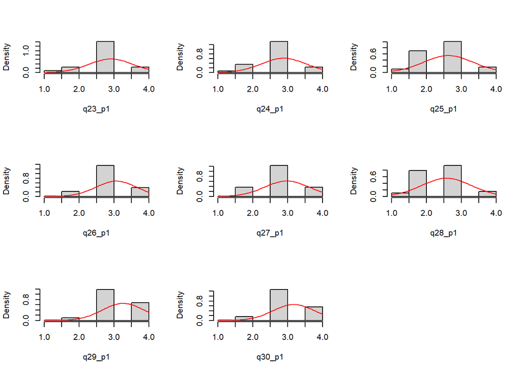

```r
#Structure at home (8)
scale_1 <- efa_vars %>%
  select(q23_p1:q30_p1)

mvn(scale_1, subset = NULL, mvnTest = "hz", univariateTest = "AD", univariatePlot = "histogram") # mvn uses listwise deletion for missing data
```

```r
# School-based involvement (10)
scale_2 <- efa_vars %>%
  select(q31_p1:q40_p1)

mvn(scale_2, subset = NULL, mvnTest = "hz", univariateTest = "AD", univariatePlot = "histogram", showOutliers = TRUE) # mvn uses listwise deletion for missing data
```

```
## $multivariateNormality
##            Test       HZ p value MVN
## 1 Henze-Zirkler 2.897971       0  NO
##
## $univariateNormality
##                Test  Variable Statistic   p value Normality
## 1  Anderson-Darling  q31_p1     11.6343  <0.001      NO
## 2  Anderson-Darling  q32_p1     14.3346  <0.001      NO
## 3  Anderson-Darling  q33_p1     10.9103  <0.001      NO
## 4  Anderson-Darling  q34_p1      9.1804  <0.001      NO
## 5  Anderson-Darling  q35_p1     12.6903  <0.001      NO
## 6  Anderson-Darling  q36_p1     10.5008  <0.001      NO
## 7  Anderson-Darling  q37_p1      9.5229  <0.001      NO
## 8  Anderson-Darling  q38_p1      7.5000  <0.001      NO
## 9  Anderson-Darling  q39_p1      8.3537  <0.001      NO
## 10 Anderson-Darling  q40_p1     10.1439  <0.001      NO
##
## $Descriptives
##         n     Mean   Std.Dev Median Min Max 25th 75th        Skew   Kurtosis
## q31_p1 92 2.836957 0.6337950    3.0   1   4    3    3 -0.62851415  1.0083048
## q32_p1 92 3.021739 0.5737530    3.0   1   4    3    3 -0.68797613  2.5120862
## q33_p1 92 3.032609 0.6368033    3.0   1   4    3    3 -0.53091025  1.1251797
## q34_p1 92 2.913043 0.6898347    3.0   1   4    3    3 -0.48484043  0.5008993
## q35_p1 92 2.913043 0.6228642    3.0   1   4    3    3 -0.75252264  1.6633320
## q36_p1 92 2.913043 0.6402639    3.0   1   4    3    3 -0.42273983  0.6707514
## q37_p1 92 2.576087 0.6668558    2.5   1   4    2    3  0.49381004 -0.5133389
## q38_p1 92 2.456522 0.7173370    2.0   1   4    2    3 -0.02605149 -0.3290566
## q39_p1 92 2.336957 0.6838349    2.0   1   4    2    3  0.08373148 -0.2411214
## q40_p1 92 2.902174 0.6472220    3.0   1   4    3    3 -0.38995430  0.5306021
##
## $multivariateOutliers
## NULL
```

```r
describe(scale_2)
```

```
##        vars  n mean   sd median trimmed  mad min max range  skew kurtosis   se
## q31_p1    1 93 2.84 0.63      3    2.84 0.00   1   4     3 -0.64     1.05 0.07
## q32_p1    2 94 3.02 0.57      3    3.05 0.00   1   4     3 -0.69     2.63 0.06
## q33_p1    3 94 3.02 0.64      3    3.05 0.00   1   4     3 -0.51     1.02 0.07
## q34_p1    4 94 2.91 0.68      3    2.93 0.00   1   4     3 -0.50     0.58 0.07
## q35_p1    5 94 2.91 0.62      3    2.93 0.00   1   4     3 -0.77     1.77 0.06
## q36_p1    6 94 2.91 0.65      3    2.92 0.00   1   4     3 -0.38     0.51 0.07
## q37_p1    7 93 2.58 0.66      3    2.51 1.48   1   4     3  0.48    -0.52 0.07
## q38_p1    8 93 2.45 0.71      2    2.47 1.48   1   4     3 -0.01    -0.32 0.07
## q39_p1    9 94 2.33 0.68      2    2.36 0.00   1   4     3  0.11    -0.20 0.07
## q40_p1   10 94 2.91 0.65      3    2.92 0.00   1   4     3 -0.38     0.51 0.07
```

[figure not shown]

```r
# Parent Belongingness in School (7)
scale_3 <- efa_vars %>%
  select(q47_p1, q48_p1, q51_p1, q52_p1, q53_p1, q59_p1, q60_p1)

mvn(scale_3, subset = NULL, mvnTest = "hz", univariateTest = "AD", univariatePlot = "histogram") # mvn uses listwise deletion for missing data
```

```
## $multivariateNormality
##            Test       HZ p value MVN
## 1 Henze-Zirkler 13.84766       0  NO
##
## $univariateNormality
##               Test  Variable Statistic   p value Normality
## 1 Anderson-Darling  q47_p1     10.6452  <0.001      NO
## 2 Anderson-Darling  q48_p1     15.1682  <0.001      NO
## 3 Anderson-Darling  q51_p1     15.3738  <0.001      NO
## 4 Anderson-Darling  q52_p1     19.2736  <0.001      NO
## 5 Anderson-Darling  q53_p1     18.0733  <0.001      NO
## 6 Anderson-Darling  q59_p1     18.5845  <0.001      NO
## 7 Anderson-Darling  q60_p1     18.9764  <0.001      NO
##
## $Descriptives
##         n     Mean   Std.Dev Median Min Max 25th 75th        Skew   Kurtosis
## q47_p1 87 2.839080 0.6447203      3   1   4    3    3 -0.61678344  0.9338092
## q48_p1 87 3.034483 0.4929332      3   2   4    3    3  0.08010463  1.0368838
## q51_p1 87 3.034483 0.5159835      3   1   4    3    3 -0.44949362  2.7691667
## q52_p1 87 3.287356 0.4551526      3   3   4    3    4  0.92364413 -1.1598179
## q53_p1 87 3.160920 0.4542708      3   2   4    3    3  0.62163424  0.7574132
## q59_p1 87 3.149425 0.4453568      3   2   4    3    3  0.65885338  0.9868203
## q60_p1 87 3.183908 0.4453568      3   2   4    3    3  0.78696567  0.5032144
```

```r
describe(scale_3)
```

```
##        vars  n mean   sd median trimmed mad min max range  skew kurtosis   se
## q47_p1    1 93 2.82 0.64      3    2.81   0   1   4     3 -0.56     0.76 0.07
## q48_p1    2 93 2.99 0.54      3    3.00   0   1   4     3 -0.41     1.84 0.06
## q51_p1    3 91 3.03 0.50      3    3.04   0   1   4     3 -0.45     3.03 0.05
## q52_p1    4 94 3.27 0.49      3    3.24   0   2   4     2  0.49    -0.55 0.05
## q53_p1    5 94 3.14 0.48      3    3.12   0   2   4     2  0.39     0.75 0.05
## q59_p1    6 91 3.14 0.44      3    3.10   0   2   4     2  0.71     1.18 0.05
## q60_p1    7 90 3.17 0.46      3    3.12   0   2   4     2  0.63     0.68 0.05
```

[figure not shown]

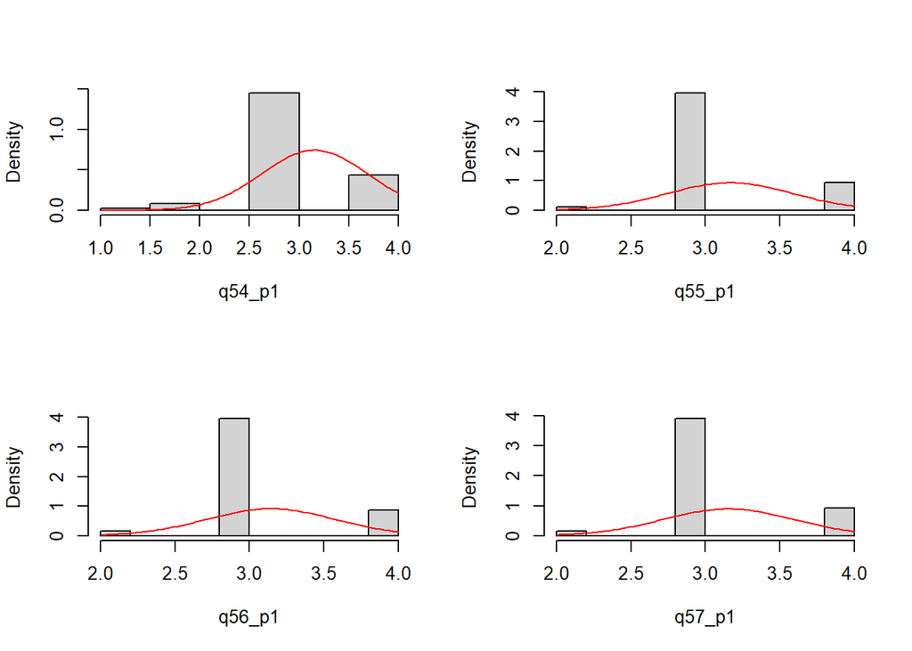

```
## $multivariateNormality
##            Test       HZ p value MVN
## 1 Henze-Zirkler 30.03589       0  NO
##
## $univariateNormality
##               Test  Variable Statistic   p value Normality
## 1 Anderson-Darling  q54_p1     14.9596  <0.001      NO
## 2 Anderson-Darling  q55_p1     20.9449  <0.001      NO
## 3 Anderson-Darling  q56_p1     20.0158  <0.001      NO
## 4 Anderson-Darling  q57_p1     19.4885  <0.001      NO
##
## $Descriptives
##         n     Mean   Std.Dev Median Min Max 25th 75th       Skew  Kurtosis
## q54_p1 91 3.153846 0.5358913      3   1   4    3    3 -0.3042106 2.1832832
## q55_p1 91 3.164835 0.4285307      3   2   4    3    3  0.8964269 0.9122077
## q56_p1 91 3.142857 0.4364358      3   2   4    3    3  0.7122056 1.1750392
## q57_p1 91 3.153846 0.4452983      3   2   4    3    3  0.6760229 0.9328520
```

```r
# Parent Endorsement of School (4)
scale_4 <- efa_vars %>%
  select(q54_p1:q57_p1)

mvn(scale_4, subset = NULL, mvnTest = "hz", univariateTest = "AD", univariatePlot = "histogram")
```

```r
describe(scale_4)
```

```
##        vars  n mean   sd median trimmed mad min max range  skew kurtosis   se
## q54_p1    1 94 3.16 0.53      3    3.16   0   1   4     3 -0.29     2.13 0.06
## q55_p1    2 94 3.17 0.43      3    3.12   0   2   4     2  0.89     0.81 0.04
## q56_p1    3 92 3.15 0.44      3    3.11   0   2   4     2  0.69     0.98 0.05
## q57_p1    4 93 3.15 0.44      3    3.11   0   2   4     2  0.70     1.02 0.05
```

```r
# plots <- split.default(scale_4, names(scale_4)) %>%
#   map(., setNames, nm = "var") %>%
#   map(., rownames_to_column) %>%
#   imap(., ~ {
#     ggplot(.x, aes(var)) +
#       geom_bar() +
#       labs(title = .y)
#     })
#
# plots
```

# issue of sparseness

```r
#contingency tables?
```

[output not shown]

# Homework Involvement (17)

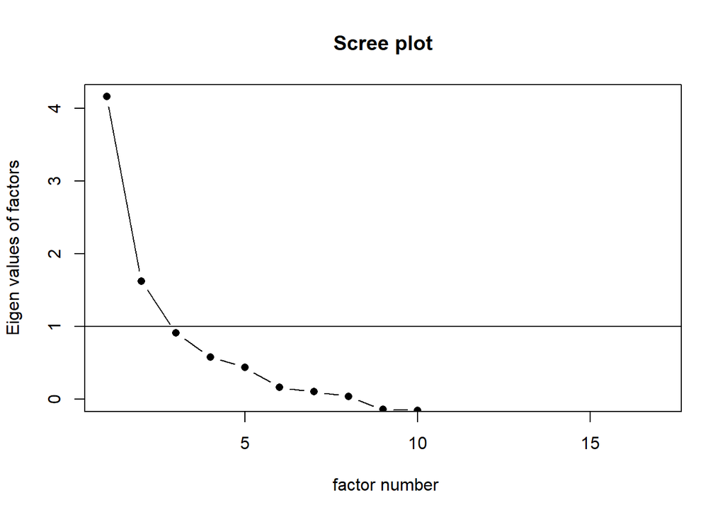

```r
# Homework Involvement (17)
scale_7 <- efa_vars %>%
  select(q82_p1:q98_p1)

# Poly corr matrix
poly_scale_7 <- polychoric(scale_7)
poly_scale_7_mat <- data.frame(poly_scale_7$rho)

# scree plot
scree(poly_scale_7_mat,factors=TRUE,pc=FALSE,main="Scree plot",hline=NULL,add=FALSE)
```

```r
# EFA
fa(scale_7, n.obs = NA, rotate = "none", fm = "uls", cor = "poly")
```

```
## Factor Analysis using method =  uls
## Call: fa(r = scale_7, n.obs = NA, rotate = "none", fm = "uls", cor = "poly")
## Standardized loadings (pattern matrix) based upon correlation matrix
##         ULS1      h2   u2 com
## q82_p1 -0.28 0.07769 0.92   1
## q83_p1 -0.02 0.00045 1.00   1
## q84_p1  0.42 0.17936 0.82   1
## q85_p1  0.55 0.30516 0.69   1
## q86_p1  0.54 0.29246 0.71   1
## q87_p1  0.59 0.35348 0.65   1
## q88_p1  0.55 0.29885 0.70   1
## q89_p1  0.65 0.42823 0.57   1
## q90_p1  0.54 0.28823 0.71   1
## q91_p1  0.33 0.10678 0.89   1
## q92_p1  0.28 0.07899 0.92   1
## q93_p1  0.61 0.37166 0.63   1
## q94_p1  0.53 0.27657 0.72   1
## q95_p1  0.52 0.27069 0.73   1
## q96_p1  0.52 0.26636 0.73   1
## q97_p1  0.52 0.26759 0.73   1
## q98_p1  0.55 0.29810 0.70   1
##
##                ULS1
## SS loadings    4.16
## Proportion Var 0.24
##
## Mean item complexity =  1
## Test of the hypothesis that 1 factor is sufficient.
##
## The degrees of freedom for the null model are  136  and the objective function was  11.71 with Chi Square of  1012.81
## The degrees of freedom for the model are 119  and the objective function was  8.7
##
## The root mean square of the residuals (RMSR) is  0.15
## The df corrected root mean square of the residuals is  0.16
##
## The harmonic number of observations is  92 with the empirical chi square  557.46  with prob <  6.9e-58
## The total number of observations was  94  with Likelihood Chi Square =  746.48  with prob <  1.5e-91
##
## Tucker Lewis Index of factoring reliability =  0.175
## RMSEA index =  0.237  and the 90 % confidence intervals are  0.222 0.255
## BIC =  205.83
## Fit based upon off diagonal values = 0.73
## Measures of factor score adequacy
##                                                   ULS1
## Correlation of (regression) scores with factors   0.93
## Multiple R square of scores with factors          0.86
## Minimum correlation of possible factor scores     0.72
```

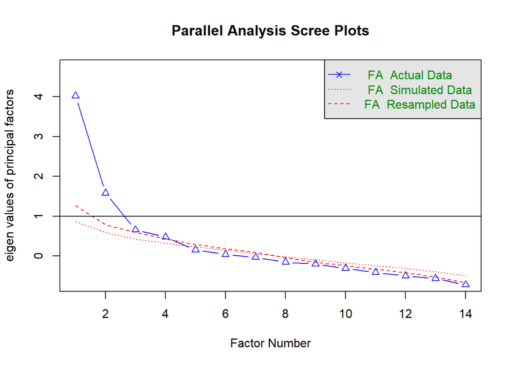

```
## Parallel analysis suggests that the number of factors =  4  and the number of components =  NA
```

```r
#removing 82, 83, 92
scale_7.1 <- efa_vars %>%
  select(q84_p1:q91_p1, q93_p1:q98_p1)

# PARALLEL ANALYSIS - Homework Involvement (17)
fa.parallel(scale_7.1, n.obs=NULL, fm="uls", fa="fa", nfactors=1, main="Parallel Analysis Scree Plots", n.iter=20, error.bars=FALSE, se.bars=FALSE, SMC=FALSE, ylabel=NULL, show.legend=TRUE, sim=TRUE, quant=.95, cor="poly", use="pairwise", plot=TRUE, correct=.5) # parrallel analysis suggest 4 factors
```

```r
# 4 factors
fa(scale_7.1, nfactors = 4, n.obs = NA, rotate = "quartimin", fm = "uls", cor = "poly")
```

```
## Factor Analysis using method =  uls
## Call: fa(r = scale_7.1, nfactors = 4, n.obs = NA, rotate = "quartimin",
##     fm = "uls", cor = "poly")
## Standardized loadings (pattern matrix) based upon correlation matrix
##         ULS1  ULS2  ULS4  ULS3   h2   u2 com
## q84_p1 -0.03  0.93 -0.09 -0.04 0.84 0.16 1.0
## q85_p1  0.02  0.86 -0.03  0.17 0.83 0.17 1.1
## q86_p1  0.44  0.14  0.28 -0.08 0.41 0.59 2.0
## q87_p1  0.78 -0.15  0.02  0.20 0.68 0.32 1.2
## q88_p1  0.77 -0.15  0.22 -0.14 0.74 0.26 1.3
## q89_p1  0.53  0.20  0.24 -0.03 0.51 0.49 1.7
## q90_p1  0.29  0.10  0.09  0.44 0.39 0.61 2.0
## q91_p1 -0.07  0.02  0.07  0.86 0.74 0.26 1.0
## q93_p1 -0.02  0.70  0.35 -0.02 0.64 0.36 1.5
## q94_p1  0.12 -0.03  0.78  0.12 0.74 0.26 1.1
## q95_p1  0.06  0.41  0.45 -0.08 0.42 0.58 2.1
## q96_p1  0.58  0.15 -0.11  0.02 0.35 0.65 1.2
## q97_p1  0.64  0.24 -0.20 -0.09 0.43 0.57 1.5
## q98_p1  0.33  0.26 -0.12  0.41 0.43 0.57 2.9
##
##                       ULS1 ULS2 ULS4 ULS3
## SS loadings           2.84 2.63 1.38 1.29
## Proportion Var        0.20 0.19 0.10 0.09
## Cumulative Var        0.20 0.39 0.49 0.58
## Proportion Explained  0.35 0.32 0.17 0.16
## Cumulative Proportion 0.35 0.67 0.84 1.00
##
##  With factor correlations of
##      ULS1 ULS2 ULS4 ULS3
## ULS1 1.00 0.16 0.38 0.15
## ULS2 0.16 1.00 0.09 0.22
## ULS4 0.38 0.09 1.00 0.10
## ULS3 0.15 0.22 0.10 1.00
##
## Mean item complexity =  1.5
## Test of the hypothesis that 4 factors are sufficient.
##
## The degrees of freedom for the null model are  91  and the objective function was  8.63 with Chi Square of  754.89
## The degrees of freedom for the model are 41  and the objective function was  2.44
##
## The root mean square of the residuals (RMSR) is  0.05
## The df corrected root mean square of the residuals is  0.07
##
## The harmonic number of observations is  92 with the empirical chi square  41.67  with prob <  0.44
## The total number of observations was  94  with Likelihood Chi Square =  207.34  with prob <  4.3e-24
##
## Tucker Lewis Index of factoring reliability =  0.424
## RMSEA index =  0.207  and the 90 % confidence intervals are  0.181 0.238
## BIC =  21.07
## Fit based upon off diagonal values = 0.98
## Measures of factor score adequacy
##                                                   ULS1 ULS2 ULS4 ULS3
## Correlation of (regression) scores with factors   0.93 0.96 0.89 0.90
## Multiple R square of scores with factors          0.87 0.92 0.79 0.82
## Minimum correlation of possible factor scores     0.74 0.84 0.59 0.64
```

```r
# 3 factors
fa(scale_7.1, nfactors = 3, n.obs = NA, rotate = "quartimin", fm = "uls", cor = "poly")
```

```
## Factor Analysis using method =  uls
## Call: fa(r = scale_7.1, nfactors = 3, n.obs = NA, rotate = "quartimin",
##     fm = "uls", cor = "poly")
## Standardized loadings (pattern matrix) based upon correlation matrix
##         ULS1  ULS2  ULS3   h2   u2 com
## q84_p1 -0.10  0.92 -0.04 0.81 0.19 1.0
## q85_p1 -0.03  0.86  0.17 0.83 0.17 1.1
## q86_p1  0.61  0.18 -0.07 0.41 0.59 1.2
## q87_p1  0.72 -0.15  0.28 0.65 0.35 1.4
## q88_p1  0.90 -0.12 -0.10 0.77 0.23 1.1
## q89_p1  0.66  0.23  0.00 0.52 0.48 1.2
## q90_p1  0.28  0.09  0.49 0.41 0.59 1.7
## q91_p1 -0.08  0.02  0.78 0.60 0.40 1.0
## q93_p1  0.19  0.72 -0.04 0.58 0.42 1.1
## q94_p1  0.54  0.06  0.08 0.33 0.67 1.1
## q95_p1  0.34  0.44 -0.10 0.32 0.68 2.0
## q96_p1  0.45  0.14  0.09 0.27 0.73 1.3
## q97_p1  0.45  0.21  0.01 0.27 0.73 1.4
## q98_p1  0.18  0.23  0.47 0.41 0.59 1.8
##
##                       ULS1 ULS2 ULS3
## SS loadings           3.22 2.65 1.32
## Proportion Var        0.23 0.19 0.09
## Cumulative Var        0.23 0.42 0.51
## Proportion Explained  0.45 0.37 0.18
## Cumulative Proportion 0.45 0.82 1.00
##
##  With factor correlations of
##      ULS1 ULS2 ULS3
## ULS1 1.00 0.14 0.19
## ULS2 0.14 1.00 0.27
## ULS3 0.19 0.27 1.00
##
## Mean item complexity =  1.3
## Test of the hypothesis that 3 factors are sufficient.
##
## The degrees of freedom for the null model are  91  and the objective function was  8.63 with Chi Square of  754.89
## The degrees of freedom for the model are 52  and the objective function was  2.93
##
## The root mean square of the residuals (RMSR) is  0.07
## The df corrected root mean square of the residuals is  0.09
##
## The harmonic number of observations is  92 with the empirical chi square  81.78  with prob <  0.0052
## The total number of observations was  94  with Likelihood Chi Square =  250.91  with prob <  7.6e-28
##
## Tucker Lewis Index of factoring reliability =  0.462
## RMSEA index =  0.201  and the 90 % confidence intervals are  0.178 0.228
## BIC =  14.66
## Fit based upon off diagonal values = 0.95
## Measures of factor score adequacy
##                                                   ULS1 ULS2 ULS3
## Correlation of (regression) scores with factors   0.94 0.96 0.86
## Multiple R square of scores with factors          0.89 0.91 0.75
## Minimum correlation of possible factor scores     0.78 0.83 0.49
```

```r
#Reliability: Homework Involvement (17)
scale_7.1_fa_1 <- efa_vars %>%
  select(q86_p1:q89_p1, q94_p1, q96_p1, q97_p1)

alpha(scale_7.1_fa_1) # 0.78
```

```
##
## Reliability analysis
## Call: alpha(x = scale_7.1_fa_1)
##
##   raw_alpha std.alpha G6(smc) average_r S/N   ase mean   sd median_r
##       0.78      0.78    0.78      0.34 3.6 0.035  2.7 0.67     0.34
##
##     95% confidence boundaries
##          lower alpha upper
## Feldt     0.70  0.78  0.84
## Duhachek  0.71  0.78  0.85
##
##  Reliability if an item is dropped:
##        raw_alpha std.alpha G6(smc) average_r S/N alpha se  var.r med.r
## q86_p1      0.74      0.75    0.74      0.33 3.0    0.041 0.0149  0.33
## q87_p1      0.74      0.74    0.73      0.32 2.8    0.042 0.0123  0.33
## q88_p1      0.72      0.72    0.70      0.30 2.6    0.045 0.0086  0.29
## q89_p1      0.74      0.75    0.75      0.33 3.0    0.041 0.0170  0.33
## q94_p1      0.77      0.77    0.76      0.36 3.4    0.037 0.0109  0.34
## q96_p1      0.76      0.77    0.75      0.35 3.3    0.037 0.0141  0.37
## q97_p1      0.76      0.77    0.75      0.36 3.4    0.038 0.0116  0.37
##
##  Item statistics
##         n raw.r std.r r.cor r.drop mean   sd
## q86_p1 93  0.66  0.68  0.60   0.53  2.8 0.91
## q87_p1 92  0.69  0.71  0.66   0.57  3.3 0.89
## q88_p1 91  0.76  0.77  0.75   0.64  3.0 1.03
## q89_p1 93  0.69  0.68  0.59   0.53  2.3 1.19
## q94_p1 91  0.58  0.58  0.47   0.40  2.3 1.03
## q96_p1 93  0.62  0.60  0.50   0.43  2.6 1.11
## q97_p1 93  0.59  0.58  0.48   0.42  2.7 0.98
##
## Non missing response frequency for each item
##           1    2    3    4 miss
## q86_p1 0.11 0.20 0.46 0.23 0.01
## q87_p1 0.07 0.09 0.28 0.57 0.02
## q88_p1 0.13 0.13 0.34 0.40 0.03
## q89_p1 0.38 0.18 0.22 0.23 0.01
## q94_p1 0.29 0.27 0.31 0.13 0.03
## q96_p1 0.25 0.17 0.34 0.24 0.01
## q97_p1 0.18 0.16 0.47 0.18 0.01
```

```r
scale_7.1_fa_2 <- efa_vars %>%
  select(q84_p1, q85_p1, q93_p1, q95_p1)

alpha(scale_7.1_fa_2) # 0.70 (0.77 if removing 95)
```

```
##
## Reliability analysis
## Call: alpha(x = scale_7.1_fa_2)
##
##   raw_alpha std.alpha G6(smc) average_r S/N   ase mean   sd median_r
##        0.7      0.74    0.74      0.41 2.8 0.052  3.3 0.65      0.4
##
##     95% confidence boundaries
##          lower alpha upper
## Feldt     0.58   0.7  0.79
## Duhachek  0.59   0.7  0.80
##
##  Reliability if an item is dropped:
##        raw_alpha std.alpha G6(smc) average_r S/N alpha se var.r med.r
## q84_p1      0.61      0.63    0.56      0.37 1.7    0.069 0.021  0.38
## q85_p1      0.58      0.61    0.52      0.34 1.5    0.071 0.012  0.38
## q93_p1      0.58      0.66    0.66      0.39 1.9    0.080 0.094  0.21
## q95_p1      0.77      0.79    0.75      0.56 3.7    0.042 0.029  0.50
##
##  Item statistics
##         n raw.r std.r r.cor r.drop mean   sd
## q84_p1 92  0.72  0.79  0.75   0.56  3.7 0.67
## q85_p1 93  0.76  0.82  0.80   0.58  3.7 0.76
## q93_p1 93  0.79  0.77  0.64   0.56  3.4 0.93
## q95_p1 93  0.70  0.60  0.37   0.34  2.3 1.15
##
## Non missing response frequency for each item
##           1    2    3    4 miss
## q84_p1 0.03 0.02 0.15 0.79 0.02
## q85_p1 0.05 0.02 0.10 0.83 0.01
## q93_p1 0.08 0.09 0.22 0.62 0.01
## q95_p1 0.37 0.20 0.24 0.19 0.01
```

```r
scale_7.1_fa_3 <- efa_vars %>%
  select(q90_p1, q91_p1, q98_p1)

alpha(scale_7.1_fa_3) # 0.59
```

```
##
## Reliability analysis
## Call: alpha(x = scale_7.1_fa_3)
##
##   raw_alpha std.alpha G6(smc) average_r S/N   ase mean  sd median_r
##       0.59      0.59     0.5      0.33 1.5 0.072  2.7 0.8     0.34
##
##     95% confidence boundaries
##          lower alpha upper
## Feldt     0.43  0.59  0.72
## Duhachek  0.45  0.59  0.74
##
##  Reliability if an item is dropped:
##        raw_alpha std.alpha G6(smc) average_r  S/N alpha se var.r med.r
## q90_p1      0.51      0.51    0.34      0.34 1.02    0.102    NA  0.34
## q91_p1      0.43      0.43    0.28      0.28 0.77    0.117    NA  0.28
## q98_p1      0.54      0.54    0.37      0.37 1.17    0.095    NA  0.37
##
##  Item statistics
##         n raw.r std.r r.cor r.drop mean  sd
## q90_p1 93  0.74  0.74  0.52   0.40  2.6 1.1
## q91_p1 93  0.77  0.77  0.58   0.44  2.4 1.1
## q98_p1 93  0.73  0.72  0.48   0.37  3.2 1.1
##
## Non missing response frequency for each item
##           1    2    3    4 miss
## q90_p1 0.24 0.10 0.45 0.22 0.01
## q91_p1 0.30 0.15 0.40 0.15 0.01
## q98_p1 0.15 0.05 0.24 0.56 0.01
```

# Monitoring (5)

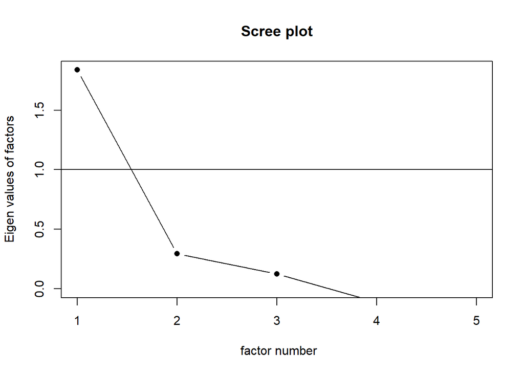

```r
#Monitoring (5)
scale_10 <- efa_vars %>%
  select(q137_p1, q139_p1, q140_p1, q143_p1, q144_p1)

# Poly corr matrix
poly_scale_10 <- polychoric(scale_10)
poly_scale_10_mat <- data.frame(poly_scale_10$rho)

# scree plot
scree(poly_scale_10_mat,factors=TRUE,pc=FALSE,main="Scree plot",hline=NULL,add=FALSE)
```

```r
# EFA
fa(scale_10, n.obs = NA, rotate = "none", fm = "uls", cor = "poly")
```

```
## Factor Analysis using method =  uls
## Call: fa(r = scale_10, n.obs = NA, rotate = "none", fm = "uls", cor = "poly")
## Standardized loadings (pattern matrix) based upon correlation matrix
##         ULS1   h2   u2 com
## q137_p1 0.45 0.21 0.79   1
## q139_p1 0.66 0.44 0.56   1
## q140_p1 0.63 0.40 0.60   1
## q143_p1 0.75 0.56 0.44   1
## q144_p1 0.48 0.23 0.77   1
##
##                ULS1
## SS loadings    1.84
## Proportion Var 0.37
##
## Mean item complexity =  1
## Test of the hypothesis that 1 factor is sufficient.
##
## The degrees of freedom for the null model are  10  and the objective function was  1.25 with Chi Square of  113.38
## The degrees of freedom for the model are 5  and the objective function was  0.3
##
## The root mean square of the residuals (RMSR) is  0.1
## The df corrected root mean square of the residuals is  0.14
##
## The harmonic number of observations is  93 with the empirical chi square  19.34  with prob <  0.0017
## The total number of observations was  94  with Likelihood Chi Square =  27.25  with prob <  5.1e-05
##
## Tucker Lewis Index of factoring reliability =  0.566
## RMSEA index =  0.217  and the 90 % confidence intervals are  0.143 0.302
## BIC =  4.53
## Fit based upon off diagonal values = 0.93
## Measures of factor score adequacy
##                                                   ULS1
## Correlation of (regression) scores with factors   0.88
## Multiple R square of scores with factors          0.77
## Minimum correlation of possible factor scores     0.54
```

```r
#Reliability: Monitoring (5)

alpha(scale_10) # 0.62
```

```
##
## Reliability analysis
## Call: alpha(x = scale_10)
##
##   raw_alpha std.alpha G6(smc) average_r S/N   ase mean   sd median_r
##       0.62      0.62    0.61      0.25 1.6 0.062  3.1 0.38     0.26
##
##     95% confidence boundaries
##          lower alpha upper
## Feldt     0.48  0.62  0.73
## Duhachek  0.50  0.62  0.74
##
##  Reliability if an item is dropped:
##         raw_alpha std.alpha G6(smc) average_r S/N alpha se  var.r med.r
## q137_p1      0.60      0.61    0.58      0.28 1.5    0.067 0.0190  0.26
## q139_p1      0.55      0.54    0.51      0.23 1.2    0.075 0.0224  0.22
## q140_p1      0.53      0.54    0.49      0.23 1.2    0.080 0.0104  0.23
## q143_p1      0.53      0.53    0.50      0.22 1.1    0.080 0.0183  0.23
## q144_p1      0.61      0.61    0.55      0.28 1.5    0.064 0.0098  0.26
##
##  Item statistics
##          n raw.r std.r r.cor r.drop mean   sd
## q137_p1 94  0.59  0.57  0.38   0.31  2.9 0.64
## q139_p1 94  0.64  0.67  0.55   0.42  3.2 0.52
## q140_p1 94  0.71  0.66  0.56   0.43  2.8 0.70
## q143_p1 93  0.69  0.68  0.56   0.45  3.2 0.61
## q144_p1 92  0.52  0.57  0.41   0.27  3.3 0.53
##
## Non missing response frequency for each item
##            1    2    3    4 miss
## q137_p1 0.03 0.14 0.69 0.14 0.00
## q139_p1 0.00 0.05 0.69 0.26 0.00
## q140_p1 0.05 0.20 0.64 0.11 0.00
## q143_p1 0.03 0.01 0.70 0.26 0.01
## q144_p1 0.00 0.03 0.62 0.35 0.02
```

# Appropriate Discipline (7) <<<<< ultra-Heywood case>>>>>>>

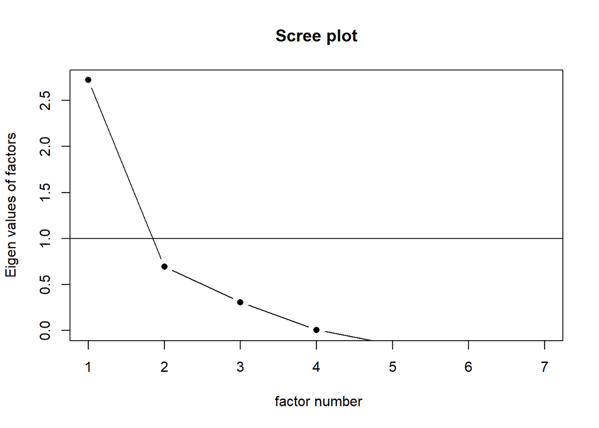

```r
#Appropriate Discipline (7)
scale_9 <- efa_vars %>%
  select(q128_p1:q131_p1, q133_p1, q134_p1, q136_p1)

# Poly corr matrix
poly_scale_9 <- polychoric(scale_9)
poly_scale_9_mat <- data.frame(poly_scale_9$rho)

# scree plot
scree(poly_scale_9_mat,factors=TRUE,pc=FALSE,main="Scree plot",hline=NULL,add=FALSE)
```

```r
# EFA
fa(scale_9, n.obs = NA, rotate = "none", fm = "uls", cor = "poly")
```

```
## Factor Analysis using method =  uls
## Call: fa(r = scale_9, n.obs = NA, rotate = "none", fm = "uls", cor = "poly")
## Standardized loadings (pattern matrix) based upon correlation matrix
##          ULS1     h2     u2 com
## q128_p1  1.01 1.0275 -0.028   1
## q129_p1  0.92 0.8506  0.149   1
## q130_p1  0.70 0.4952  0.505   1
## q131_p1  0.22 0.0465  0.954   1
## q133_p1  0.04 0.0015  0.998   1
## q134_p1  0.52 0.2705  0.730   1
## q136_p1 -0.13 0.0169  0.983   1
##
##                ULS1
## SS loadings    2.71
## Proportion Var 0.39
##
## Mean item complexity =  1
## Test of the hypothesis that 1 factor is sufficient.
##
## The degrees of freedom for the null model are  21  and the objective function was  4.23 with Chi Square of  380.36
## The degrees of freedom for the model are 14  and the objective function was  1.68
##
## The root mean square of the residuals (RMSR) is  0.15
## The df corrected root mean square of the residuals is  0.19
##
## The harmonic number of observations is  92 with the empirical chi square  90.7  with prob <  2.8e-13
## The total number of observations was  94  with Likelihood Chi Square =  150.01  with prob <  7.1e-25
##
## Tucker Lewis Index of factoring reliability =  0.428
## RMSEA index =  0.321  and the 90 % confidence intervals are  0.278 0.371
## BIC =  86.41
## Fit based upon off diagonal values = 0.85
```

```r
# Appropriate Discipline EFA iterations

# iteration 1
scale_9.1 <- efa_vars %>%
  select(q129_p1:q131_p1, q133_p1, q134_p1, q136_p1)

fa(scale_9.1, n.obs = NA, rotate = "none", fm = "uls", cor = "poly") # item 129 now appears as heywood
```

```
## Factor Analysis using method =  uls
## Call: fa(r = scale_9.1, n.obs = NA, rotate = "none", fm = "uls", cor = "poly")
## Standardized loadings (pattern matrix) based upon correlation matrix
##          ULS1     h2     u2 com
## q129_p1  1.02 1.0493 -0.049   1
## q130_p1  0.68 0.4612  0.539   1
## q131_p1  0.14 0.0196  0.980   1
## q133_p1  0.06 0.0038  0.996   1
## q134_p1  0.43 0.1831  0.817   1
## q136_p1 -0.13 0.0173  0.983   1
##
##                ULS1
## SS loadings    1.73
## Proportion Var 0.29
##
## Mean item complexity =  1
## Test of the hypothesis that 1 factor is sufficient.
##
## The degrees of freedom for the null model are  15  and the objective function was  1.93 with Chi Square of  173.79
## The degrees of freedom for the model are 9  and the objective function was  0.82
##
## The root mean square of the residuals (RMSR) is  0.17
## The df corrected root mean square of the residuals is  0.22
##
## The harmonic number of observations is  92 with the empirical chi square  80.52  with prob <  1.3e-13
## The total number of observations was  94  with Likelihood Chi Square =  73.83  with prob <  2.7e-12
##
## Tucker Lewis Index of factoring reliability =  0.314
## RMSEA index =  0.277  and the 90 % confidence intervals are  0.222 0.339
## BIC =  32.94
## Fit based upon off diagonal values = 0.67
```

```r
# iteration 2
scale_9.2 <- efa_vars %>%
  select(q130_p1, q131_p1, q133_p1, q134_p1, q136_p1)

fa(scale_9.2, n.obs = NA, rotate = "none", fm = "uls", cor = "poly") # no more heywood
```

```
## Factor Analysis using method =  uls
## Call: fa(r = scale_9.2, n.obs = NA, rotate = "none", fm = "uls", cor = "poly")
## Standardized loadings (pattern matrix) based upon correlation matrix
##         ULS1    h2   u2 com
## q130_p1 0.13 0.016 0.98   1
## q131_p1 0.44 0.192 0.81   1
## q133_p1 0.61 0.372 0.63   1
## q134_p1 0.14 0.020 0.98   1
## q136_p1 0.64 0.411 0.59   1
##
##                ULS1
## SS loadings    1.01
## Proportion Var 0.20
##
## Mean item complexity =  1
## Test of the hypothesis that 1 factor is sufficient.
##
## The degrees of freedom for the null model are  10  and the objective function was  0.48 with Chi Square of  43.44
## The degrees of freedom for the model are 5  and the objective function was  0.17
##
## The root mean square of the residuals (RMSR) is  0.11
## The df corrected root mean square of the residuals is  0.16
##
## The harmonic number of observations is  92 with the empirical chi square  23.78  with prob <  0.00024
## The total number of observations was  94  with Likelihood Chi Square =  15.63  with prob <  0.008
##
## Tucker Lewis Index of factoring reliability =  0.358
## RMSEA index =  0.15  and the 90 % confidence intervals are  0.07 0.239
## BIC =  -7.08
## Fit based upon off diagonal values = 0.72
## Measures of factor score adequacy
##                                                   ULS1
## Correlation of (regression) scores with factors   0.78
## Multiple R square of scores with factors          0.61
## Minimum correlation of possible factor scores     0.22
```

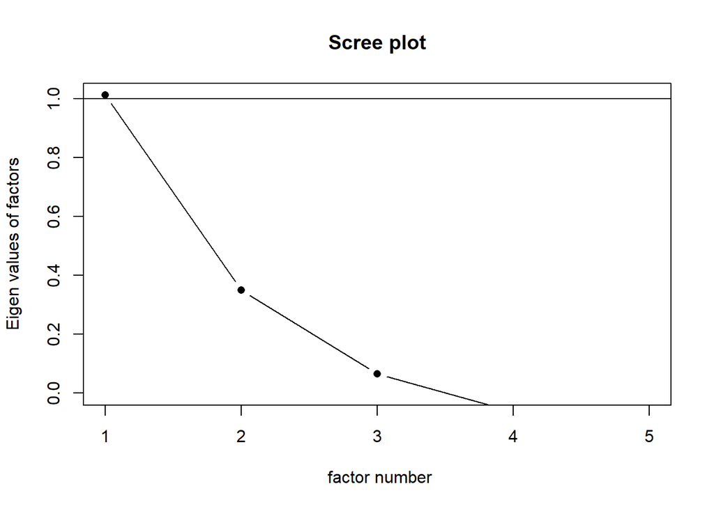

```r
poly_scale_9.2 <- polychoric(scale_9.2)
poly_scale_9.2_mat <- data.frame(poly_scale_9.2$rho)

# scree plot
scree(poly_scale_9.2_mat,factors=TRUE,pc=FALSE,main="Scree plot",hline=NULL,add=FALSE)
```

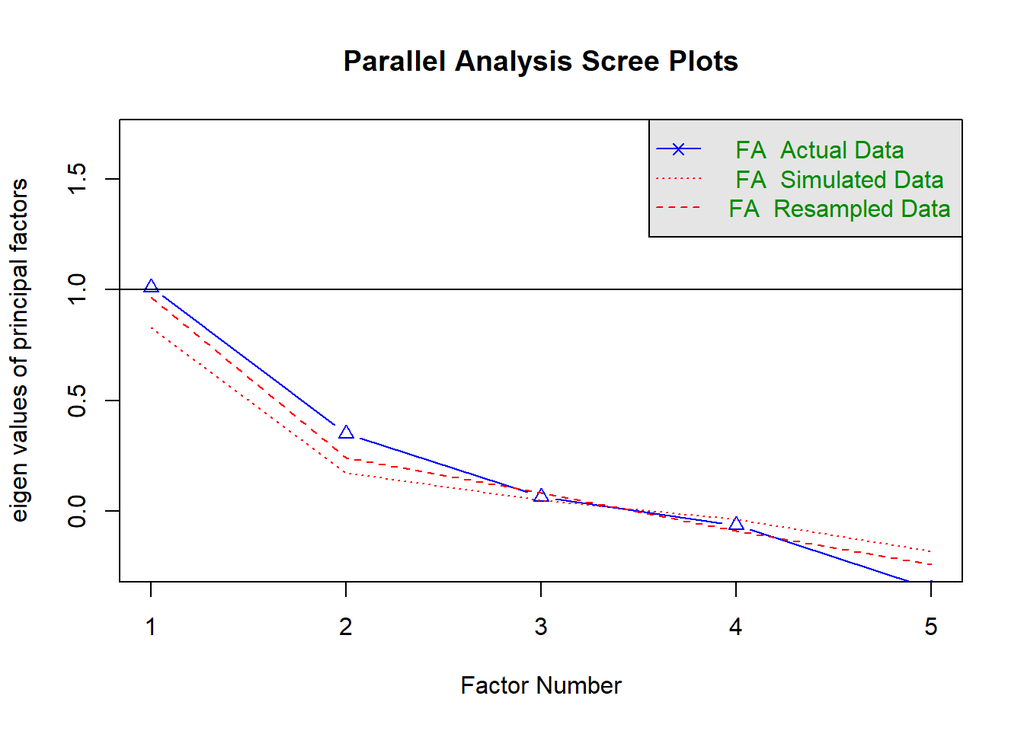

```
## Parallel analysis suggests that the number of factors =  0  and the number of components =  NA
```

```r
# PARALLEL ANALYSIS - Appropriate discipline (7)
fa.parallel(scale_9.2, n.obs=NULL, fm="uls", fa="fa", nfactors=1, main="Parallel Analysis Scree Plots", n.iter=20, error.bars=FALSE, se.bars=FALSE, SMC=FALSE, ylabel=NULL, show.legend=TRUE, sim=TRUE, quant=.95, cor="poly", use="pairwise", plot=TRUE, correct=.5)
```

```r
# 2 factors (JUST TO CHECK)
# fa(scale_9.2, nfactors = 2, n.obs = NA, rotate = "quartimin", fm = "uls", cor = "poly") # first factor made of just one item and heywood case

# iteration 3
scale_9.3 <- efa_vars %>%
  select(q131_p1, q133_p1, q136_p1)

fa(scale_9.3, n.obs = NA, rotate = "none", fm = "uls", cor = "poly")
```

```
## Factor Analysis using method =  uls
## Call: fa(r = scale_9.3, n.obs = NA, rotate = "none", fm = "uls", cor = "poly")
## Standardized loadings (pattern matrix) based upon correlation matrix
##         ULS1   h2   u2 com
## q131_p1 0.38 0.15 0.85   1
## q133_p1 0.62 0.39 0.61   1
## q136_p1 0.69 0.48 0.52   1
##
##                ULS1
## SS loadings    1.01
## Proportion Var 0.34
##
## Mean item complexity =  1
## Test of the hypothesis that 1 factor is sufficient.
##
## The degrees of freedom for the null model are  3  and the objective function was  0.3 with Chi Square of  27.34
## The degrees of freedom for the model are 0  and the objective function was  0
##
## The root mean square of the residuals (RMSR) is  0
## The df corrected root mean square of the residuals is  NA
##
## The harmonic number of observations is  91 with the empirical chi square  0  with prob <  NA
## The total number of observations was  94  with Likelihood Chi Square =  0  with prob <  NA
##
## Tucker Lewis Index of factoring reliability =  -Inf
## Fit based upon off diagonal values = 1
## Measures of factor score adequacy
##                                                   ULS1
## Correlation of (regression) scores with factors   0.80
## Multiple R square of scores with factors          0.63
## Minimum correlation of possible factor scores     0.27
```

```r
# Appropriate Discipline reliability
scale_9.3 <- efa_vars %>%
  select(q131_p1, q133_p1, q136_p1)

alpha(scale_9.3) # 0.50 NOT GOOD
```

```
##
## Reliability analysis
## Call: alpha(x = scale_9.3)
##
##   raw_alpha std.alpha G6(smc) average_r  S/N   ase mean   sd median_r
##        0.5       0.5    0.41      0.25 0.98 0.088  2.8 0.49     0.19
##
##     95% confidence boundaries
##          lower alpha upper
## Feldt     0.30   0.5  0.65
## Duhachek  0.33   0.5  0.67
##
##  Reliability if an item is dropped:
##         raw_alpha std.alpha G6(smc) average_r  S/N alpha se var.r med.r
## q131_p1      0.54      0.54    0.37      0.37 1.17    0.095    NA  0.37
## q133_p1      0.31      0.31    0.18      0.18 0.45    0.141    NA  0.18
## q136_p1      0.31      0.31    0.19      0.19 0.46    0.141    NA  0.19
##
##  Item statistics
##          n raw.r std.r r.cor r.drop mean   sd
## q131_p1 94  0.63  0.65  0.31   0.22  2.9 0.64
## q133_p1 91  0.74  0.73  0.52   0.37  2.8 0.72
## q136_p1 92  0.75  0.73  0.52   0.37  2.6 0.74
##
## Non missing response frequency for each item
##            1    2    3    4 miss
## q131_p1 0.00 0.26 0.59 0.16 0.00
## q133_p1 0.04 0.22 0.59 0.14 0.03
## q136_p1 0.09 0.29 0.55 0.07 0.02
```

```r
# just to check alpha with the 5 items:
scale_9.2 <- efa_vars %>%
  select(q130_p1, q131_p1, q133_p1, q134_p1, q136_p1)

alpha(scale_9.2) # 0.41 even worse!
```

```
##
## Reliability analysis
## Call: alpha(x = scale_9.2)
##
##   raw_alpha std.alpha G6(smc) average_r  S/N   ase mean   sd median_r
##       0.41       0.4     0.4      0.12 0.66 0.092    3 0.34     0.12
##
##     95% confidence boundaries
##          lower alpha upper
## Feldt     0.20  0.41  0.58
## Duhachek  0.23  0.41  0.60
##
##  Reliability if an item is dropped:
##         raw_alpha std.alpha G6(smc) average_r  S/N alpha se var.r med.r
## q130_p1      0.43      0.40    0.39     0.145 0.68    0.092 0.026 0.185
## q131_p1      0.31      0.29    0.29     0.092 0.40    0.110 0.028 0.025
## q133_p1      0.30      0.31    0.29     0.103 0.46    0.117 0.014 0.106
## q134_p1      0.42      0.39    0.35     0.136 0.63    0.092 0.020 0.123
## q136_p1      0.31      0.33    0.30     0.108 0.48    0.115 0.014 0.123
##
##  Item statistics
##          n raw.r std.r r.cor r.drop mean   sd
## q130_p1 94  0.39  0.48  0.21   0.10  3.2 0.50
## q131_p1 94  0.60  0.60  0.42   0.27  2.9 0.64
## q133_p1 91  0.64  0.57  0.42   0.29  2.8 0.72
## q134_p1 94  0.41  0.50  0.27   0.12  3.3 0.49
## q136_p1 92  0.64  0.56  0.39   0.27  2.6 0.74
##
## Non missing response frequency for each item
##            1    2    3    4 miss
## q130_p1 0.00 0.04 0.71 0.24 0.00
## q131_p1 0.00 0.26 0.59 0.16 0.00
## q133_p1 0.04 0.22 0.59 0.14 0.03
## q134_p1 0.00 0.02 0.69 0.29 0.00
## q136_p1 0.09 0.29 0.55 0.07 0.02
```

```r
#Appropriate Discipline univariate analysis

# d2 %>% #before reverse scoring
#   select(q128_p1:q131_p1, q133_p1, q134_p1, q136_p1) %>%
#   mutate(q128_p1 = as.factor(q128_p1),
#          q129_p1 = as.factor(q129_p1),
#          q130_p1 = as.factor(q130_p1),
#          q131_p1 = as.factor(q131_p1),# no one fully endorsed yelling
#          q133_p1 = as.factor(q133_p1),# 4 endorsed quiting
#          q134_p1 = as.factor(q134_p1),#8 endorsed not following
#          q136_p1 = as.factor(q136_p1)) %>%
#   summary()
```

```r
#Appropriate Discipline univariate analysis

# efa_vars %>% #after reverse scoring
#   select(q128_p1:q131_p1, q133_p1, q134_p1, q136_p1) %>%
#   mutate(q128_p1 = as.factor(q128_p1),
#          q129_p1 = as.factor(q129_p1),
#          q130_p1 = as.factor(q130_p1),
#          q131_p1 = as.factor(q131_p1),
#          q133_p1 = as.factor(q133_p1),
#          q134_p1 = as.factor(q134_p1),
#          q136_p1 = as.factor(q136_p1)) %>%
#   summary()
```

# Structure at home (8)

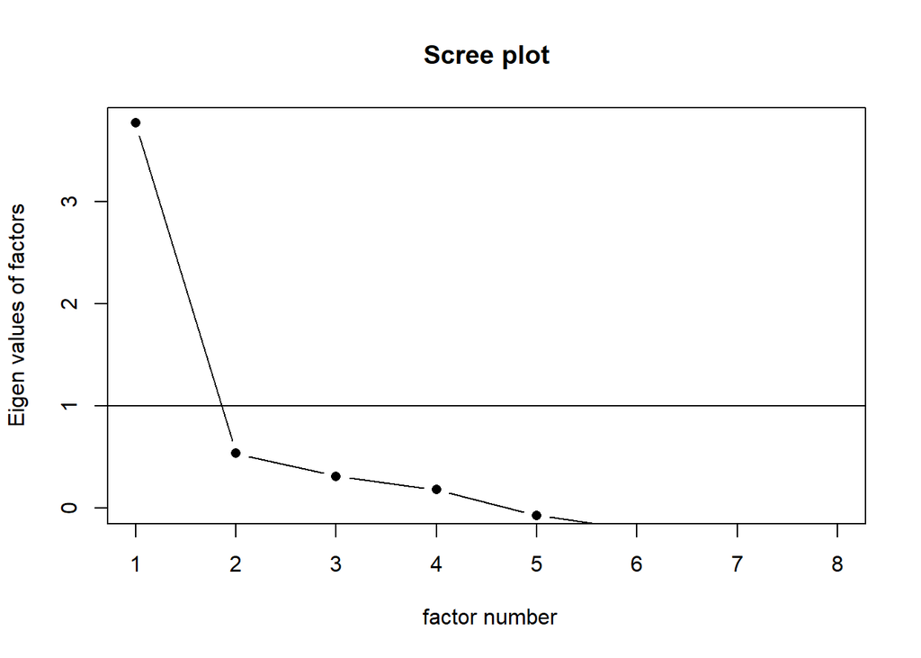

```r
# Structure at home (8)
scale_1 <- efa_vars %>%
  select(q23_p1:q30_p1)

# Poly corr matrix
poly_scale_1 <- polychoric(scale_1)
poly_scale_1_mat <- data.frame(poly_scale_1$rho)

# scree plot
scree(poly_scale_1_mat,factors=TRUE,pc=FALSE,main="Scree plot",hline=NULL,add=FALSE)
```

```r
# EFA
fa(scale_1, n.obs = NA, rotate = "none", fm = "uls", cor = "poly", sort = TRUE)
```

```
## Factor Analysis using method =  uls
## Call: fa(r = scale_1, n.obs = NA, rotate = "none", fm = "uls", cor = "poly",
##     sort = TRUE)
## Standardized loadings (pattern matrix) based upon correlation matrix
##        ULS1   h2   u2 com
## q23_p1 0.74 0.54 0.46   1
## q24_p1 0.80 0.65 0.35   1
## q25_p1 0.47 0.22 0.78   1
## q26_p1 0.67 0.45 0.55   1
## q27_p1 0.77 0.60 0.40   1
## q28_p1 0.74 0.54 0.46   1
## q29_p1 0.73 0.53 0.47   1
## q30_p1 0.49 0.24 0.76   1
##
##                ULS1
## SS loadings    3.77
## Proportion Var 0.47
##
## Mean item complexity =  1
## Test of the hypothesis that 1 factor is sufficient.
##
## The degrees of freedom for the null model are  28  and the objective function was  5.56 with Chi Square of  497.29
## The degrees of freedom for the model are 20  and the objective function was  2.37
##
## The root mean square of the residuals (RMSR) is  0.12
## The df corrected root mean square of the residuals is  0.14
##
## The harmonic number of observations is  93 with the empirical chi square  70.96  with prob <  1.3e-07
## The total number of observations was  94  with Likelihood Chi Square =  210.94  with prob <  7.6e-34
##
## Tucker Lewis Index of factoring reliability =  0.426
## RMSEA index =  0.319  and the 90 % confidence intervals are  0.282 0.36
## BIC =  120.07
## Fit based upon off diagonal values = 0.94
## Measures of factor score adequacy
##                                                   ULS1
## Correlation of (regression) scores with factors   0.94
## Multiple R square of scores with factors          0.89
## Minimum correlation of possible factor scores     0.78
```

```r
#Reliability: Structure at home (8)

alpha(scale_1) # 0.82
```

```
##
## Reliability analysis
## Call: alpha(x = scale_1)
##
##   raw_alpha std.alpha G6(smc) average_r S/N   ase mean   sd median_r
##       0.82      0.82    0.84      0.36 4.4 0.029  2.9 0.43     0.35
##
##     95% confidence boundaries
##          lower alpha upper
## Feldt     0.75  0.82  0.87
## Duhachek  0.76  0.82  0.87
##
##  Reliability if an item is dropped:
##        raw_alpha std.alpha G6(smc) average_r S/N alpha se var.r med.r
## q23_p1      0.79      0.79    0.80      0.36 3.9    0.033 0.018  0.35
## q24_p1      0.78      0.78    0.79      0.34 3.5    0.035 0.018  0.33
## q25_p1      0.82      0.82    0.83      0.39 4.4    0.029 0.016  0.40
## q26_p1      0.80      0.80    0.82      0.36 3.9    0.032 0.022  0.34
## q27_p1      0.78      0.78    0.80      0.34 3.6    0.035 0.020  0.34
## q28_p1      0.78      0.78    0.79      0.34 3.6    0.035 0.016  0.32
## q29_p1      0.79      0.79    0.80      0.35 3.7    0.033 0.021  0.33
## q30_p1      0.82      0.82    0.83      0.39 4.5    0.029 0.013  0.40
##
##  Item statistics
##         n raw.r std.r r.cor r.drop mean   sd
## q23_p1 94  0.67  0.67  0.62   0.54  2.9 0.65
## q24_p1 94  0.75  0.74  0.72   0.64  2.9 0.65
## q25_p1 94  0.56  0.54  0.45   0.40  2.6 0.72
## q26_p1 93  0.64  0.66  0.58   0.53  3.1 0.59
## q27_p1 93  0.74  0.74  0.70   0.63  3.0 0.65
## q28_p1 93  0.74  0.72  0.69   0.62  2.6 0.71
## q29_p1 94  0.69  0.70  0.65   0.57  3.3 0.61
## q30_p1 94  0.50  0.52  0.42   0.35  3.2 0.60
##
## Non missing response frequency for each item
##           1    2    3    4 miss
## q23_p1 0.04 0.12 0.70 0.14 0.00
## q24_p1 0.03 0.17 0.67 0.13 0.00
## q25_p1 0.05 0.36 0.50 0.09 0.00
## q26_p1 0.01 0.11 0.69 0.19 0.01
## q27_p1 0.01 0.18 0.61 0.19 0.01
## q28_p1 0.05 0.40 0.47 0.08 0.01
## q29_p1 0.01 0.05 0.59 0.35 0.00
## q30_p1 0.01 0.07 0.64 0.28 0.00
```

# Parent-Child Conversations About School (14)

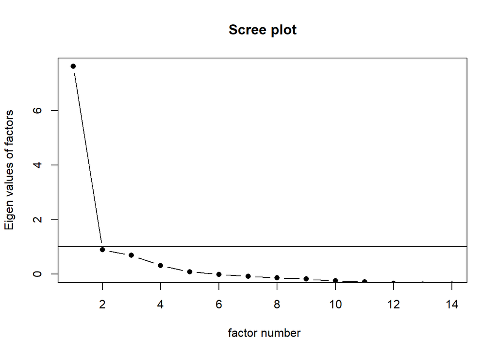

```r
#Parent-Child Conversations About School (14)
scale_6 <- efa_vars %>%
  select(q68_p1:q81_p1)

# Poly corr matrix
poly_scale_6 <- polychoric(scale_6)
poly_scale_6_mat <- data.frame(poly_scale_6$rho)

# scree plot
scree(poly_scale_6_mat,factors=TRUE,pc=FALSE,main="Scree plot",hline=NULL,add=FALSE)
```

```r
# EFA
fa(scale_6, n.obs = NA, rotate = "none", fm = "uls", cor = "poly")
```

```
## Factor Analysis using method =  uls
## Call: fa(r = scale_6, n.obs = NA, rotate = "none", fm = "uls", cor = "poly")
## Standardized loadings (pattern matrix) based upon correlation matrix
##        ULS1   h2   u2 com
## q68_p1 0.68 0.46 0.54   1
## q69_p1 0.79 0.62 0.38   1
## q70_p1 0.68 0.46 0.54   1
## q71_p1 0.74 0.55 0.45   1
## q72_p1 0.73 0.53 0.47   1
## q73_p1 0.64 0.40 0.60   1
## q74_p1 0.89 0.80 0.20   1
## q75_p1 0.77 0.59 0.41   1
## q76_p1 0.74 0.55 0.45   1
## q77_p1 0.86 0.74 0.26   1
## q78_p1 0.79 0.62 0.38   1
## q79_p1 0.77 0.59 0.41   1
## q80_p1 0.65 0.42 0.58   1
## q81_p1 0.54 0.29 0.71   1
##
##                ULS1
## SS loadings    7.62
## Proportion Var 0.54
##
## Mean item complexity =  1
## Test of the hypothesis that 1 factor is sufficient.
##
## The degrees of freedom for the null model are  91  and the objective function was  13.74 with Chi Square of  1202.35
## The degrees of freedom for the model are 77  and the objective function was  5.1
##
## The root mean square of the residuals (RMSR) is  0.1
## The df corrected root mean square of the residuals is  0.11
##
## The harmonic number of observations is  94 with the empirical chi square  183.78  with prob <  1e-10
## The total number of observations was  94  with Likelihood Chi Square =  443  with prob <  8.1e-53
##
## Tucker Lewis Index of factoring reliability =  0.608
## RMSEA index =  0.225  and the 90 % confidence intervals are  0.206 0.247
## BIC =  93.17
## Fit based upon off diagonal values = 0.96
## Measures of factor score adequacy
##                                                   ULS1
## Correlation of (regression) scores with factors   0.98
## Multiple R square of scores with factors          0.95
## Minimum correlation of possible factor scores     0.91
```

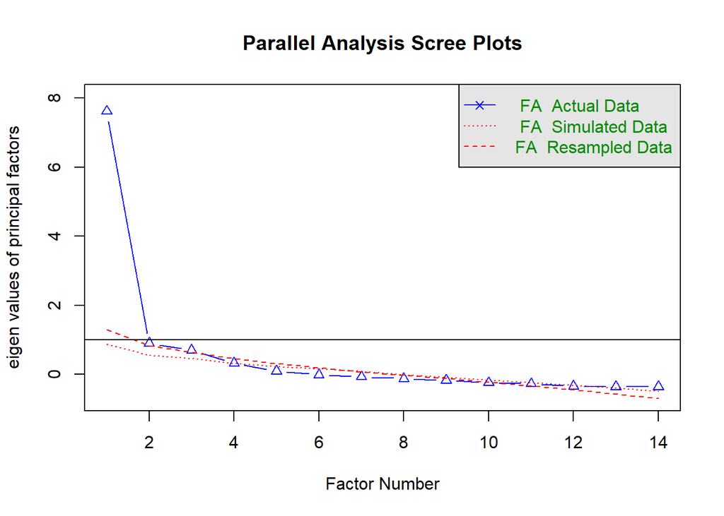

```
## Parallel analysis suggests that the number of factors =  3  and the number of components =  NA
```

```r
# PARALLEL ANALYSIS Parent-Child Conversations
fa.parallel(scale_6, n.obs=NULL, fm="uls", fa="fa", nfactors=1, main="Parallel Analysis Scree Plots", n.iter=20, error.bars=FALSE, se.bars=FALSE, SMC=FALSE, ylabel=NULL, show.legend=TRUE, sim=TRUE, quant=.95, cor="poly", use="pairwise", plot=TRUE, correct=.5) # parrallel analysis suggest 3 factors
```

```r
# 3 factors - iteration 2
fa(scale_6, nfactors = 3, n.obs = NA, rotate = "quartimin", fm = "uls", cor = "poly") # item 74 cross loaded in factor 1 and 2
```

```
## Factor Analysis using method =  uls
## Call: fa(r = scale_6, nfactors = 3, n.obs = NA, rotate = "quartimin",
##     fm = "uls", cor = "poly")
## Standardized loadings (pattern matrix) based upon correlation matrix
##         ULS1  ULS3  ULS2   h2    u2 com
## q68_p1  0.18  0.56  0.05 0.52 0.483 1.2
## q69_p1  0.01  0.90  0.02 0.85 0.148 1.0
## q70_p1 -0.01  0.87 -0.06 0.69 0.306 1.0
## q71_p1  0.06  0.73  0.08 0.67 0.327 1.0
## q72_p1  0.15  0.30  0.42 0.55 0.449 2.1
## q73_p1  0.08  0.27  0.41 0.44 0.564 1.8
## q74_p1  0.46  0.14  0.45 0.81 0.192 2.2
## q75_p1  0.16  0.02  0.78 0.79 0.214 1.1
## q76_p1  0.74  0.00  0.12 0.65 0.347 1.1
## q77_p1  0.87  0.13 -0.02 0.91 0.089 1.0
## q78_p1  0.98 -0.06  0.00 0.87 0.127 1.0
## q79_p1  0.77  0.12 -0.01 0.71 0.289 1.1
## q80_p1  0.11 -0.10  0.82 0.69 0.313 1.1
## q81_p1 -0.22  0.12  0.82 0.60 0.397 1.2
##
##                       ULS1 ULS3 ULS2
## SS loadings           3.68 3.13 2.94
## Proportion Var        0.26 0.22 0.21
## Cumulative Var        0.26 0.49 0.70
## Proportion Explained  0.38 0.32 0.30
## Cumulative Proportion 0.38 0.70 1.00
##
##  With factor correlations of
##      ULS1 ULS3 ULS2
## ULS1 1.00 0.65 0.54
## ULS3 0.65 1.00 0.55
## ULS2 0.54 0.55 1.00
##
## Mean item complexity =  1.3
## Test of the hypothesis that 3 factors are sufficient.
##
## The degrees of freedom for the null model are  91  and the objective function was  13.74 with Chi Square of  1202.35
## The degrees of freedom for the model are 52  and the objective function was  2.34
##
## The root mean square of the residuals (RMSR) is  0.05
## The df corrected root mean square of the residuals is  0.06
##
## The harmonic number of observations is  94 with the empirical chi square  34.64  with prob <  0.97
## The total number of observations was  94  with Likelihood Chi Square =  200.3  with prob <  2.8e-19
##
## Tucker Lewis Index of factoring reliability =  0.761
## RMSEA index =  0.174  and the 90 % confidence intervals are  0.15 0.201
## BIC =  -35.95
## Fit based upon off diagonal values = 0.99
## Measures of factor score adequacy
##                                                   ULS1 ULS3 ULS2
## Correlation of (regression) scores with factors   0.98 0.97 0.95
## Multiple R square of scores with factors          0.96 0.93 0.90
## Minimum correlation of possible factor scores     0.92 0.87 0.80
```

```r
# iteration 3
scale_6.1 <- efa_vars %>%
  select(q68_p1:q73_p1, q75_p1:q81_p1)

# 3 factors - # iteration 3
fa(scale_6.1, nfactors = 3, n.obs = NA, rotate = "quartimin", fm = "uls", cor = "poly") # item 72 cross loaded in factor 2 and 3
```

```
## Factor Analysis using method =  uls
## Call: fa(r = scale_6.1, nfactors = 3, n.obs = NA, rotate = "quartimin",
##     fm = "uls", cor = "poly")
## Standardized loadings (pattern matrix) based upon correlation matrix
##         ULS1  ULS3  ULS2   h2    u2 com
## q68_p1  0.16  0.59  0.02 0.52 0.484 1.1
## q69_p1  0.00  0.92  0.02 0.87 0.133 1.0
## q70_p1  0.01  0.84 -0.04 0.68 0.320 1.0
## q71_p1  0.08  0.71  0.10 0.67 0.332 1.1
## q72_p1  0.14  0.33  0.39 0.53 0.472 2.2
## q73_p1  0.11  0.25  0.44 0.46 0.539 1.7
## q75_p1  0.16  0.07  0.73 0.74 0.261 1.1
## q76_p1  0.74  0.01  0.13 0.66 0.340 1.1
## q77_p1  0.84  0.16 -0.02 0.89 0.111 1.1
## q78_p1  0.99 -0.08  0.01 0.90 0.097 1.0
## q79_p1  0.76  0.13  0.00 0.71 0.288 1.1
## q80_p1  0.13 -0.12  0.85 0.74 0.257 1.1
## q81_p1 -0.21  0.13  0.80 0.60 0.404 1.2
##
##                       ULS1 ULS3 ULS2
## SS loadings           3.32 3.07 2.57
## Proportion Var        0.26 0.24 0.20
## Cumulative Var        0.26 0.49 0.69
## Proportion Explained  0.37 0.34 0.29
## Cumulative Proportion 0.37 0.71 1.00
##
##  With factor correlations of
##      ULS1 ULS3 ULS2
## ULS1 1.00 0.63 0.52
## ULS3 0.63 1.00 0.53
## ULS2 0.52 0.53 1.00
##
## Mean item complexity =  1.2
## Test of the hypothesis that 3 factors are sufficient.
##
## The degrees of freedom for the null model are  78  and the objective function was  11.52 with Chi Square of  1012.27
## The degrees of freedom for the model are 42  and the objective function was  1.64
##
## The root mean square of the residuals (RMSR) is  0.04
## The df corrected root mean square of the residuals is  0.06
##
## The harmonic number of observations is  94 with the empirical chi square  25.67  with prob <  0.98
## The total number of observations was  94  with Likelihood Chi Square =  140.6  with prob <  1.5e-12
##
## Tucker Lewis Index of factoring reliability =  0.799
## RMSEA index =  0.158  and the 90 % confidence intervals are  0.13 0.188
## BIC =  -50.21
## Fit based upon off diagonal values = 0.99
## Measures of factor score adequacy
##                                                   ULS1 ULS3 ULS2
## Correlation of (regression) scores with factors   0.98 0.97 0.94
## Multiple R square of scores with factors          0.96 0.94 0.88
## Minimum correlation of possible factor scores     0.92 0.87 0.77
```

```r
# iteration 4
scale_6.2 <- efa_vars %>%
  select(q68_p1:q71_p1, q73_p1, q75_p1:q81_p1)

# 3 factors - # iteration 4
fa(scale_6.2, nfactors = 3, n.obs = NA, rotate = "quartimin", fm = "uls", cor = "poly")
```

```
## Factor Analysis using method =  uls
## Call: fa(r = scale_6.2, nfactors = 3, n.obs = NA, rotate = "quartimin",
##     fm = "uls", cor = "poly")
## Standardized loadings (pattern matrix) based upon correlation matrix
##         ULS1  ULS3  ULS2   h2    u2 com
## q68_p1  0.16  0.59  0.02 0.51 0.487 1.2
## q69_p1  0.00  0.92  0.03 0.88 0.125 1.0
## q70_p1  0.01  0.84 -0.04 0.68 0.321 1.0
## q71_p1  0.08  0.71  0.10 0.67 0.328 1.1
## q73_p1  0.09  0.26  0.44 0.46 0.540 1.7
## q75_p1  0.13  0.10  0.73 0.75 0.251 1.1
## q76_p1  0.74  0.00  0.12 0.65 0.345 1.1
## q77_p1  0.85  0.15 -0.03 0.89 0.111 1.1
## q78_p1  0.99 -0.08  0.02 0.90 0.096 1.0
## q79_p1  0.76  0.12  0.00 0.71 0.286 1.0
## q80_p1  0.08 -0.10  0.90 0.81 0.190 1.0
## q81_p1 -0.20  0.16  0.73 0.53 0.474 1.2
##
##                       ULS1 ULS3 ULS2
## SS loadings           3.22 2.89 2.34
## Proportion Var        0.27 0.24 0.19
## Cumulative Var        0.27 0.51 0.70
## Proportion Explained  0.38 0.34 0.28
## Cumulative Proportion 0.38 0.72 1.00
##
##  With factor correlations of
##      ULS1 ULS3 ULS2
## ULS1 1.00 0.64 0.53
## ULS3 0.64 1.00 0.52
## ULS2 0.53 0.52 1.00
##
## Mean item complexity =  1.1
## Test of the hypothesis that 3 factors are sufficient.
##
## The degrees of freedom for the null model are  66  and the objective function was  10.74 with Chi Square of  946.75
## The degrees of freedom for the model are 33  and the objective function was  1.49
##
## The root mean square of the residuals (RMSR) is  0.04
## The df corrected root mean square of the residuals is  0.06
##
## The harmonic number of observations is  94 with the empirical chi square  21.76  with prob <  0.93
## The total number of observations was  94  with Likelihood Chi Square =  128.79  with prob <  3e-13
##
## Tucker Lewis Index of factoring reliability =  0.777
## RMSEA index =  0.175  and the 90 % confidence intervals are  0.145 0.209
## BIC =  -21.14
## Fit based upon off diagonal values = 0.99
## Measures of factor score adequacy
##                                                   ULS1 ULS3 ULS2
## Correlation of (regression) scores with factors   0.98 0.97 0.95
## Multiple R square of scores with factors          0.96 0.94 0.90
## Minimum correlation of possible factor scores     0.92 0.88 0.79
```

```r
#Reliability: Parent-Child Conversations About School (14)

#factor 3
scale_6.fa_3 <- efa_vars %>%
  select(q68_p1:q71_p1)

alpha(scale_6.fa_3) # 0.81
```

```
##
## Reliability analysis
## Call: alpha(x = scale_6.fa_3)
##
##   raw_alpha std.alpha G6(smc) average_r S/N   ase mean   sd median_r
##       0.81      0.81    0.79      0.52 4.3 0.032  3.5 0.59     0.59
##
##     95% confidence boundaries
##          lower alpha upper
## Feldt     0.74  0.81  0.87
## Duhachek  0.75  0.81  0.87
##
##  Reliability if an item is dropped:
##        raw_alpha std.alpha G6(smc) average_r S/N alpha se   var.r med.r
## q68_p1      0.82      0.82    0.76      0.61 4.7    0.031 0.00022  0.61
## q69_p1      0.70      0.70    0.64      0.44 2.3    0.052 0.02751  0.37
## q70_p1      0.75      0.75    0.72      0.51 3.1    0.046 0.02890  0.59
## q71_p1      0.76      0.77    0.71      0.52 3.3    0.044 0.01643  0.59
##
##  Item statistics
##         n raw.r std.r r.cor r.drop mean   sd
## q68_p1 94  0.69  0.71  0.58   0.49  3.6 0.68
## q69_p1 94  0.87  0.88  0.84   0.76  3.5 0.68
## q70_p1 94  0.83  0.81  0.72   0.65  3.4 0.82
## q71_p1 94  0.81  0.80  0.71   0.64  3.4 0.77
##
## Non missing response frequency for each item
##           1    2    3    4 miss
## q68_p1 0.02 0.04 0.26 0.68    0
## q69_p1 0.01 0.07 0.33 0.59    0
## q70_p1 0.06 0.02 0.39 0.52    0
## q71_p1 0.04 0.04 0.39 0.52    0
```

```r
#factor 2
scale_6.fa_2 <- efa_vars %>%
  select(q73_p1, q75_p1, q80_p1, q81_p1)

alpha(scale_6.fa_2) # 0.78
```

```
##
## Reliability analysis
## Call: alpha(x = scale_6.fa_2)
##
##   raw_alpha std.alpha G6(smc) average_r S/N   ase mean   sd median_r
##       0.78      0.79    0.75      0.48 3.7 0.038  3.2 0.69     0.47
##
##     95% confidence boundaries
##          lower alpha upper
## Feldt     0.70  0.78  0.84
## Duhachek  0.71  0.78  0.85
##
##  Reliability if an item is dropped:
##        raw_alpha std.alpha G6(smc) average_r S/N alpha se  var.r med.r
## q73_p1      0.77      0.78    0.71      0.54 3.5    0.042 0.0116  0.49
## q75_p1      0.67      0.68    0.59      0.41 2.1    0.059 0.0059  0.45
## q80_p1      0.69      0.69    0.61      0.43 2.3    0.057 0.0087  0.48
## q81_p1      0.77      0.77    0.71      0.53 3.4    0.042 0.0133  0.48
##
##  Item statistics
##         n raw.r std.r r.cor r.drop mean   sd
## q73_p1 94  0.73  0.72  0.56   0.50  3.2 0.92
## q75_p1 94  0.83  0.84  0.79   0.69  3.4 0.81
## q80_p1 93  0.81  0.83  0.76   0.66  3.4 0.86
## q81_p1 94  0.74  0.73  0.58   0.51  2.9 0.96
##
## Non missing response frequency for each item
##           1    2    3    4 miss
## q73_p1 0.09 0.09 0.39 0.44 0.00
## q75_p1 0.04 0.07 0.30 0.59 0.00
## q80_p1 0.04 0.12 0.26 0.58 0.01
## q81_p1 0.14 0.12 0.49 0.26 0.00
```

```r
#factor 1
scale_6.fa_1 <- efa_vars %>%
  select(q76_p1:q79_p1)

alpha(scale_6.fa_1) # 0.85
```

```
##
## Reliability analysis
## Call: alpha(x = scale_6.fa_1)
##
##   raw_alpha std.alpha G6(smc) average_r S/N   ase mean   sd median_r
##       0.85      0.86    0.83       0.6 5.9 0.025  3.5 0.62      0.6
##
##     95% confidence boundaries
##          lower alpha upper
## Feldt     0.79  0.85  0.89
## Duhachek  0.80  0.85  0.90
##
##  Reliability if an item is dropped:
##        raw_alpha std.alpha G6(smc) average_r S/N alpha se  var.r med.r
## q76_p1      0.85      0.86    0.81      0.67 6.1    0.026 0.0032  0.65
## q77_p1      0.77      0.78    0.72      0.55 3.6    0.041 0.0085  0.50
## q78_p1      0.79      0.79    0.73      0.56 3.9    0.036 0.0045  0.58
## q79_p1      0.81      0.82    0.77      0.60 4.6    0.033 0.0143  0.58
##
##  Item statistics
##         n raw.r std.r r.cor r.drop mean   sd
## q76_p1 94  0.78  0.77  0.64   0.60  3.5 0.80
## q77_p1 94  0.89  0.88  0.84   0.76  3.5 0.85
## q78_p1 94  0.84  0.86  0.82   0.75  3.6 0.60
## q79_p1 94  0.82  0.83  0.74   0.68  3.5 0.70
##
## Non missing response frequency for each item
##           1    2    3    4 miss
## q76_p1 0.05 0.03 0.26 0.66    0
## q77_p1 0.07 0.01 0.28 0.64    0
## q78_p1 0.01 0.03 0.26 0.70    0
## q79_p1 0.02 0.05 0.33 0.60    0
```

# School-based involvement (10)

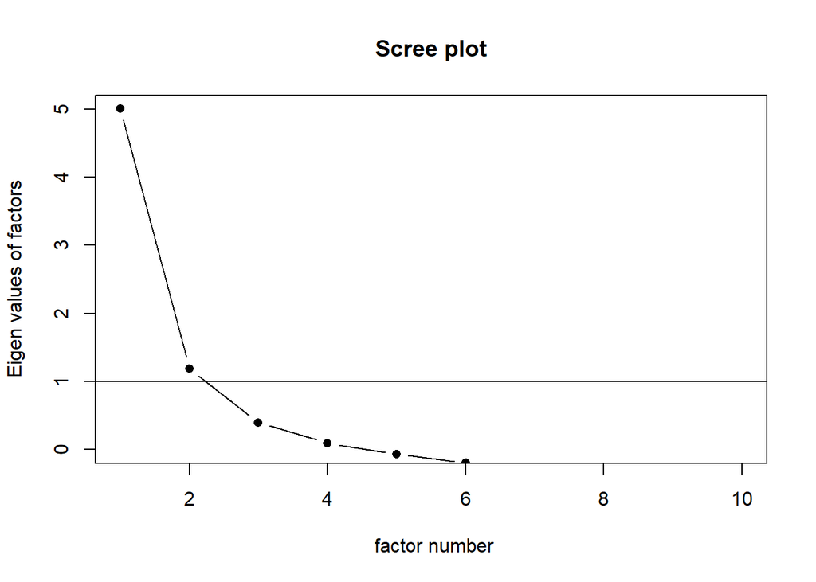

```r
# School-based involvement (10)
scale_2 <- efa_vars %>%
  select(q31_p1:q40_p1)

# Poly corr matrix
poly_scale_2 <- polychoric(scale_2)
poly_scale_2_mat <- data.frame(poly_scale_2$rho)

# scree plot
scree(poly_scale_2_mat,factors=TRUE,pc=FALSE,main="Scree plot",hline=NULL,add=FALSE) # a little ambiguous
```

```r
# EFA
fa(scale_2, n.obs = NA, rotate = "none", fm = "uls", cor = "poly")
```

```
## Factor Analysis using method =  uls
## Call: fa(r = scale_2, n.obs = NA, rotate = "none", fm = "uls", cor = "poly")
## Standardized loadings (pattern matrix) based upon correlation matrix
##        ULS1   h2   u2 com
## q31_p1 0.61 0.38 0.62   1
## q32_p1 0.72 0.52 0.48   1
## q33_p1 0.80 0.64 0.36   1
## q34_p1 0.84 0.71 0.29   1
## q35_p1 0.80 0.65 0.35   1
## q36_p1 0.68 0.47 0.53   1
## q37_p1 0.60 0.36 0.64   1
## q38_p1 0.66 0.44 0.56   1
## q39_p1 0.54 0.29 0.71   1
## q40_p1 0.75 0.56 0.44   1
##
##                ULS1
## SS loadings     5.0
## Proportion Var  0.5
##
## Mean item complexity =  1
## Test of the hypothesis that 1 factor is sufficient.
##
## The degrees of freedom for the null model are  45  and the objective function was  9.01 with Chi Square of  800.48
## The degrees of freedom for the model are 35  and the objective function was  4.18
##
## The root mean square of the residuals (RMSR) is  0.15
## The df corrected root mean square of the residuals is  0.17
##
## The harmonic number of observations is  93 with the empirical chi square  198.74  with prob <  8.8e-25
## The total number of observations was  94  with Likelihood Chi Square =  368.14  with prob <  3.5e-57
##
## Tucker Lewis Index of factoring reliability =  0.429
## RMSEA index =  0.318  and the 90 % confidence intervals are  0.291 0.35
## BIC =  209.12
## Fit based upon off diagonal values = 0.91
## Measures of factor score adequacy
##                                                   ULS1
## Correlation of (regression) scores with factors   0.96
## Multiple R square of scores with factors          0.93
## Minimum correlation of possible factor scores     0.85
```

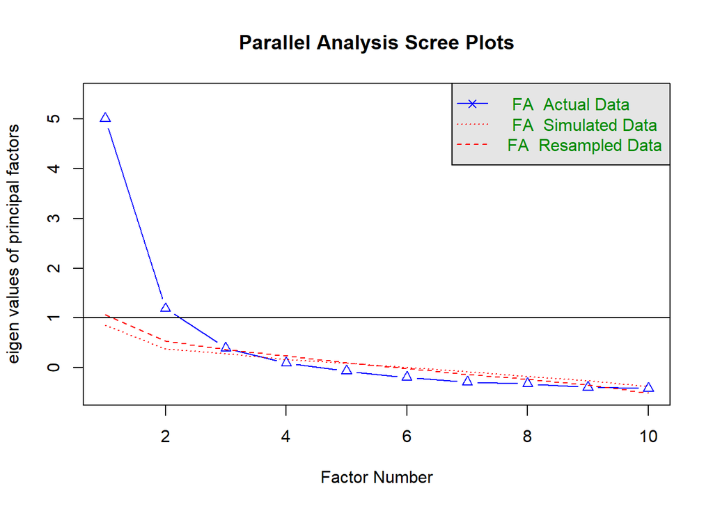

```
## Parallel analysis suggests that the number of factors =  3  and the number of components =  NA
```

```r
# PARALLEL ANALYSIS School-based involvement
fa.parallel(scale_2, n.obs=NULL, fm="uls", fa="fa", nfactors=1, main="Parallel Analysis Scree Plots", n.iter=20, error.bars=FALSE, se.bars=FALSE, SMC=FALSE, ylabel=NULL, show.legend=TRUE, sim=TRUE, quant=.95, cor="poly", use="pairwise", plot=TRUE, correct=.5)
```

```r
# suggests 3 factors, but a warning about ultra heywood case

# 3 factors
fa(scale_2, nfactors = 3, n.obs = NA, rotate = "quartimin", fm = "uls", cor = "poly") # factor 3 barely above eigenvalue >1 and crossloading items
```

```
## Factor Analysis using method =  uls
## Call: fa(r = scale_2, nfactors = 3, n.obs = NA, rotate = "quartimin",
##     fm = "uls", cor = "poly")
## Standardized loadings (pattern matrix) based upon correlation matrix
##         ULS1  ULS2  ULS3   h2   u2 com
## q31_p1  0.59  0.36 -0.49 0.78 0.22 2.6
## q32_p1  0.97 -0.13 -0.06 0.84 0.16 1.0
## q33_p1  0.94 -0.02 -0.02 0.86 0.14 1.0
## q34_p1  0.87  0.03  0.14 0.82 0.18 1.1
## q35_p1  0.63  0.17  0.25 0.65 0.35 1.5
## q36_p1  0.32  0.30  0.57 0.71 0.29 2.2
## q37_p1 -0.01  0.66  0.35 0.65 0.35 1.5
## q38_p1 -0.03  0.95 -0.07 0.85 0.15 1.0
## q39_p1 -0.05  0.77  0.00 0.56 0.44 1.0
## q40_p1  0.32  0.41  0.43 0.68 0.32 2.8
##
##                       ULS1 ULS2 ULS3
## SS loadings           3.72 2.61 1.07
## Proportion Var        0.37 0.26 0.11
## Cumulative Var        0.37 0.63 0.74
## Proportion Explained  0.50 0.35 0.14
## Cumulative Proportion 0.50 0.86 1.00
##
##  With factor correlations of
##      ULS1 ULS2 ULS3
## ULS1 1.00 0.47 0.09
## ULS2 0.47 1.00 0.23
## ULS3 0.09 0.23 1.00
##
## Mean item complexity =  1.6
## Test of the hypothesis that 3 factors are sufficient.
##
## The degrees of freedom for the null model are  45  and the objective function was  9.01 with Chi Square of  800.48
## The degrees of freedom for the model are 18  and the objective function was  1.47
##
## The root mean square of the residuals (RMSR) is  0.04
## The df corrected root mean square of the residuals is  0.06
##
## The harmonic number of observations is  93 with the empirical chi square  11.71  with prob <  0.86
## The total number of observations was  94  with Likelihood Chi Square =  127.5  with prob <  1.6e-18
##
## Tucker Lewis Index of factoring reliability =  0.629
## RMSEA index =  0.254  and the 90 % confidence intervals are  0.215 0.298
## BIC =  45.72
## Fit based upon off diagonal values = 0.99
## Measures of factor score adequacy
##                                                   ULS1 ULS2 ULS3
## Correlation of (regression) scores with factors   0.98 0.96 0.89
## Multiple R square of scores with factors          0.95 0.92 0.78
## Minimum correlation of possible factor scores     0.91 0.83 0.57
```

```r
# 2 factors
fa(scale_2, nfactors = 2, n.obs = NA, rotate = "quartimin", fm = "uls", cor = "poly") # q35_p1 cross-loaded
```

```
## Factor Analysis using method =  uls
## Call: fa(r = scale_2, nfactors = 2, n.obs = NA, rotate = "quartimin",
##     fm = "uls", cor = "poly")
## Standardized loadings (pattern matrix) based upon correlation matrix
##         ULS1  ULS2   h2   u2 com
## q31_p1  0.62  0.08 0.44 0.56 1.0
## q32_p1  0.99 -0.13 0.87 0.13 1.0
## q33_p1  0.93  0.01 0.88 0.12 1.0
## q34_p1  0.80  0.17 0.80 0.20 1.1
## q35_p1  0.55  0.37 0.62 0.38 1.8
## q36_p1  0.18  0.63 0.54 0.46 1.2
## q37_p1 -0.11  0.87 0.68 0.32 1.0
## q38_p1  0.03  0.78 0.63 0.37 1.0
## q39_p1 -0.04  0.71 0.47 0.53 1.0
## q40_p1  0.20  0.68 0.63 0.37 1.2
##
##                       ULS1 ULS2
## SS loadings           3.45 3.11
## Proportion Var        0.35 0.31
## Cumulative Var        0.35 0.66
## Proportion Explained  0.53 0.47
## Cumulative Proportion 0.53 1.00
##
##  With factor correlations of
##      ULS1 ULS2
## ULS1 1.00 0.47
## ULS2 0.47 1.00
##
## Mean item complexity =  1.1
## Test of the hypothesis that 2 factors are sufficient.
##
## The degrees of freedom for the null model are  45  and the objective function was  9.01 with Chi Square of  800.48
## The degrees of freedom for the model are 26  and the objective function was  2.07
##
## The root mean square of the residuals (RMSR) is  0.07
## The df corrected root mean square of the residuals is  0.09
##
## The harmonic number of observations is  93 with the empirical chi square  43.44  with prob <  0.017
## The total number of observations was  94  with Likelihood Chi Square =  181.48  with prob <  2.9e-25
##
## Tucker Lewis Index of factoring reliability =  0.638
## RMSEA index =  0.252  and the 90 % confidence intervals are  0.219 0.289
## BIC =  63.35
## Fit based upon off diagonal values = 0.98
## Measures of factor score adequacy
##                                                   ULS1 ULS2
## Correlation of (regression) scores with factors   0.98 0.94
## Multiple R square of scores with factors          0.96 0.89
## Minimum correlation of possible factor scores     0.92 0.78
```

```r
scale_2.1 <- efa_vars %>%
  select(q31_p1:q34_p1, q36_p1:q40_p1)

# 2 factors
fa(scale_2.1, nfactors = 2, n.obs = NA, rotate = "quartimin", fm = "uls", cor = "poly")
```

```
## Factor Analysis using method =  uls
## Call: fa(r = scale_2.1, nfactors = 2, n.obs = NA, rotate = "quartimin",
##     fm = "uls", cor = "poly")
## Standardized loadings (pattern matrix) based upon correlation matrix
##         ULS1  ULS2   h2    u2 com
## q31_p1  0.61  0.11 0.44 0.558 1.1
## q32_p1  1.01 -0.11 0.94 0.057 1.0
## q33_p1  0.93  0.04 0.91 0.094 1.0
## q34_p1  0.74  0.20 0.72 0.276 1.1
## q36_p1  0.17  0.64 0.53 0.469 1.1
## q37_p1 -0.11  0.87 0.68 0.317 1.0
## q38_p1  0.03  0.80 0.67 0.328 1.0
## q39_p1 -0.04  0.71 0.48 0.520 1.0
## q40_p1  0.18  0.67 0.59 0.413 1.1
##
##                       ULS1 ULS2
## SS loadings           3.02 2.94
## Proportion Var        0.34 0.33
## Cumulative Var        0.34 0.66
## Proportion Explained  0.51 0.49
## Cumulative Proportion 0.51 1.00
##
##  With factor correlations of
##      ULS1 ULS2
## ULS1 1.00 0.45
## ULS2 0.45 1.00
##
## Mean item complexity =  1.1
## Test of the hypothesis that 2 factors are sufficient.
##
## The degrees of freedom for the null model are  36  and the objective function was  7.35 with Chi Square of  655.55
## The degrees of freedom for the model are 19  and the objective function was  1.05
##
## The root mean square of the residuals (RMSR) is  0.07
## The df corrected root mean square of the residuals is  0.1
##
## The harmonic number of observations is  93 with the empirical chi square  32.19  with prob <  0.03
## The total number of observations was  94  with Likelihood Chi Square =  92.46  with prob <  1.2e-11
##
## Tucker Lewis Index of factoring reliability =  0.772
## RMSEA index =  0.203  and the 90 % confidence intervals are  0.163 0.246
## BIC =  6.13
## Fit based upon off diagonal values = 0.98
## Measures of factor score adequacy
##                                                   ULS1 ULS2
## Correlation of (regression) scores with factors   0.99 0.94
## Multiple R square of scores with factors          0.97 0.89
## Minimum correlation of possible factor scores     0.94 0.78
```

```r
#Reliability: School-based involvement
scale_2.1_fa_1 <- efa_vars %>%
  select(q31_p1:q34_p1)

alpha(scale_2.1_fa_1) # 0.85
```

```
##
## Reliability analysis
## Call: alpha(x = scale_2.1_fa_1)
##
##   raw_alpha std.alpha G6(smc) average_r S/N   ase mean   sd median_r
##       0.85      0.85    0.82      0.59 5.7 0.026  2.9 0.52     0.57
##
##     95% confidence boundaries
##          lower alpha upper
## Feldt     0.79  0.85  0.89
## Duhachek  0.80  0.85  0.90
##
##  Reliability if an item is dropped:
##        raw_alpha std.alpha G6(smc) average_r S/N alpha se  var.r med.r
## q31_p1      0.84      0.85    0.80      0.65 5.6    0.029 0.0106  0.60
## q32_p1      0.78      0.78    0.71      0.55 3.6    0.039 0.0024  0.55
## q33_p1      0.77      0.78    0.70      0.54 3.5    0.040 0.0021  0.53
## q34_p1      0.83      0.83    0.79      0.62 4.8    0.032 0.0179  0.55
##
##  Item statistics
##         n raw.r std.r r.cor r.drop mean   sd
## q31_p1 93  0.77  0.77  0.64   0.60  2.8 0.63
## q32_p1 94  0.86  0.87  0.83   0.75  3.0 0.57
## q33_p1 94  0.88  0.88  0.85   0.76  3.0 0.64
## q34_p1 94  0.82  0.81  0.70   0.65  2.9 0.68
##
## Non missing response frequency for each item
##           1    2    3    4 miss
## q31_p1 0.03 0.19 0.68 0.10 0.01
## q32_p1 0.02 0.09 0.74 0.15 0.00
## q33_p1 0.02 0.13 0.66 0.19 0.00
## q34_p1 0.03 0.18 0.63 0.16 0.00
```

```r
scale_2.1_fa_2 <- efa_vars %>%
  select(q36_p1:q40_p1)

alpha(scale_2.1_fa_2) # 0.82
```

```
##
## Reliability analysis
## Call: alpha(x = scale_2.1_fa_2)
##
##   raw_alpha std.alpha G6(smc) average_r S/N  ase mean   sd median_r
##       0.82      0.82     0.8      0.48 4.5 0.03  2.6 0.51     0.48
##
##     95% confidence boundaries
##          lower alpha upper
## Feldt     0.75  0.82  0.87
## Duhachek  0.76  0.82  0.88
##
##  Reliability if an item is dropped:
##        raw_alpha std.alpha G6(smc) average_r S/N alpha se  var.r med.r
## q36_p1      0.80      0.80    0.76      0.49 3.9    0.034 0.0075  0.48
## q37_p1      0.78      0.78    0.75      0.47 3.5    0.038 0.0133  0.45
## q38_p1      0.76      0.76    0.72      0.45 3.2    0.040 0.0071  0.45
## q39_p1      0.79      0.80    0.76      0.49 3.9    0.035 0.0041  0.50
## q40_p1      0.79      0.79    0.75      0.48 3.7    0.036 0.0112  0.48
##
##  Item statistics
##         n raw.r std.r r.cor r.drop mean   sd
## q36_p1 94  0.73  0.74  0.65   0.57  2.9 0.65
## q37_p1 93  0.77  0.78  0.69   0.63  2.6 0.66
## q38_p1 93  0.82  0.81  0.76   0.68  2.5 0.71
## q39_p1 94  0.74  0.73  0.65   0.58  2.3 0.68
## q40_p1 94  0.75  0.76  0.67   0.60  2.9 0.65
##
## Non missing response frequency for each item
##           1    2    3    4 miss
## q36_p1 0.02 0.19 0.64 0.15 0.00
## q37_p1 0.01 0.48 0.42 0.09 0.01
## q38_p1 0.08 0.45 0.42 0.05 0.01
## q39_p1 0.09 0.53 0.35 0.03 0.00
## q40_p1 0.02 0.19 0.64 0.15 0.00
```

# Parent Belongingness in School (5)

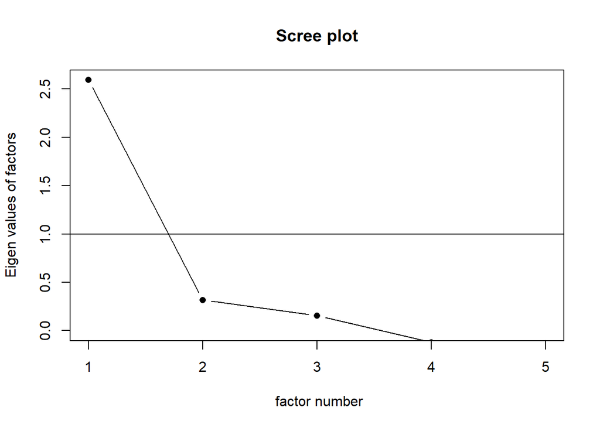

```r
# Parent Belongingness in School (5)
scale_3 <- efa_vars %>%
  select(q47_p1, q48_p1, q51_p1, q52_p1, q53_p1)

# Poly corr matrix
poly_scale_3 <- polychoric(scale_3)
poly_scale_3_mat <- data.frame(poly_scale_3$rho)

# scree plot
scree(poly_scale_3_mat,factors=TRUE,pc=FALSE,main="Scree plot",hline=NULL,add=FALSE)
```

```r
# EFA
fa(scale_3, n.obs = NA, rotate = "none", fm = "uls", cor = "poly")
```

```
## Factor Analysis using method =  uls
## Call: fa(r = scale_3, n.obs = NA, rotate = "none", fm = "uls", cor = "poly")
## Standardized loadings (pattern matrix) based upon correlation matrix
##        ULS1   h2   u2 com
## q47_p1 0.44 0.19 0.81   1
## q48_p1 0.79 0.62 0.38   1
## q51_p1 0.51 0.26 0.74   1
## q52_p1 0.82 0.67 0.33   1
## q53_p1 0.92 0.85 0.15   1
##
##                ULS1
## SS loadings    2.59
## Proportion Var 0.52
##
## Mean item complexity =  1
## Test of the hypothesis that 1 factor is sufficient.
##
## The degrees of freedom for the null model are  10  and the objective function was  2.8 with Chi Square of  253.17
## The degrees of freedom for the model are 5  and the objective function was  0.61
##
## The root mean square of the residuals (RMSR) is  0.11
## The df corrected root mean square of the residuals is  0.16
##
## The harmonic number of observations is  92 with the empirical chi square  23.66  with prob <  0.00025
## The total number of observations was  94  with Likelihood Chi Square =  54.48  with prob <  1.7e-10
##
## Tucker Lewis Index of factoring reliability =  0.59
## RMSEA index =  0.324  and the 90 % confidence intervals are  0.251 0.407
## BIC =  31.76
## Fit based upon off diagonal values = 0.95
## Measures of factor score adequacy
##                                                   ULS1
## Correlation of (regression) scores with factors   0.95
## Multiple R square of scores with factors          0.90
## Minimum correlation of possible factor scores     0.81
```

```r
#reliability parent Belongingness in School (5)
alpha(scale_3) # 0.72
```

```
##
## Reliability analysis
## Call: alpha(x = scale_3)
##
##   raw_alpha std.alpha G6(smc) average_r S/N   ase mean   sd median_r
##       0.72      0.73    0.74      0.36 2.8 0.047    3 0.37     0.33
##
##     95% confidence boundaries
##          lower alpha upper
## Feldt     0.62  0.72  0.80
## Duhachek  0.63  0.72  0.81
##
##  Reliability if an item is dropped:
##        raw_alpha std.alpha G6(smc) average_r S/N alpha se var.r med.r
## q47_p1      0.74      0.74    0.73      0.42 2.9    0.045 0.038  0.41
## q48_p1      0.65      0.67    0.67      0.34 2.1    0.060 0.032  0.31
## q51_p1      0.70      0.73    0.72      0.40 2.7    0.052 0.042  0.38
## q52_p1      0.64      0.65    0.63      0.32 1.9    0.060 0.023  0.28
## q53_p1      0.63      0.63    0.61      0.30 1.7    0.063 0.015  0.33
##
##  Item statistics
##         n raw.r std.r r.cor r.drop mean   sd
## q47_p1 93  0.64  0.59  0.42   0.35  2.8 0.64
## q48_p1 93  0.72  0.73  0.64   0.53  3.0 0.54
## q51_p1 91  0.63  0.62  0.46   0.39  3.0 0.50
## q52_p1 94  0.74  0.76  0.72   0.56  3.3 0.49
## q53_p1 94  0.77  0.79  0.76   0.61  3.1 0.48
##
## Non missing response frequency for each item
##           1    2    3    4 miss
## q47_p1 0.03 0.22 0.66 0.10 0.01
## q48_p1 0.01 0.12 0.74 0.13 0.01
## q51_p1 0.01 0.08 0.78 0.13 0.03
## q52_p1 0.00 0.02 0.69 0.29 0.00
## q53_p1 0.00 0.05 0.76 0.19 0.00
```

# Parent Endorsement of School (4) <<< ultra-Heywood case>>>

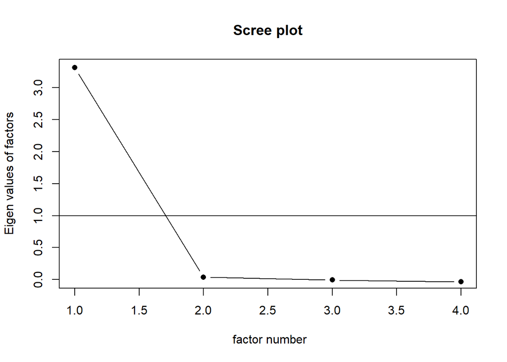

```r
# Parent Endorsement of School (4)
scale_4 <- efa_vars %>%
  select(q54_p1:q57_p1)

# Poly corr matrix
poly_scale_4 <- polychoric(scale_4)
poly_scale_4_mat <- data.frame(poly_scale_4$rho)

# scree plot
scree(poly_scale_4_mat,factors=TRUE,pc=FALSE,main="Scree plot",hline=NULL,add=FALSE)
```

```r
# EFA
fa(scale_4, n.obs = NA, rotate = "none", fm = "uls", cor = "poly")
```

```
## Factor Analysis using method =  uls
## Call: fa(r = scale_4, n.obs = NA, rotate = "none", fm = "uls", cor = "poly")
## Standardized loadings (pattern matrix) based upon correlation matrix
##        ULS1   h2       u2 com
## q54_p1 0.65 0.42  5.8e-01   1
## q55_p1 1.00 1.00 -7.9e-06   1
## q56_p1 0.98 0.95  4.9e-02   1
## q57_p1 0.97 0.94  6.4e-02   1
##
##                ULS1
## SS loadings    3.31
## Proportion Var 0.83
##
## Mean item complexity =  1
## Test of the hypothesis that 1 factor is sufficient.
##
## The degrees of freedom for the null model are  6  and the objective function was  6.29 with Chi Square of  571.69
## The degrees of freedom for the model are 2  and the objective function was  0.28
##
## The root mean square of the residuals (RMSR) is  0.01
## The df corrected root mean square of the residuals is  0.03
##
## The harmonic number of observations is  93 with the empirical chi square  0.25  with prob <  0.88
## The total number of observations was  94  with Likelihood Chi Square =  24.98  with prob <  3.8e-06
##
## Tucker Lewis Index of factoring reliability =  0.877
## RMSEA index =  0.349  and the 90 % confidence intervals are  0.237 0.481
## BIC =  15.89
## Fit based upon off diagonal values = 1
```

```r
alpha(scale_4) #.88
```

```
##
## Reliability analysis
## Call: alpha(x = scale_4)
##
##   raw_alpha std.alpha G6(smc) average_r S/N   ase mean  sd median_r
##       0.88      0.89    0.88      0.67   8 0.022  3.2 0.4     0.68
##
##     95% confidence boundaries
##          lower alpha upper
## Feldt     0.83  0.88  0.91
## Duhachek  0.84  0.88  0.92
##
##  Reliability if an item is dropped:
##        raw_alpha std.alpha G6(smc) average_r  S/N alpha se   var.r med.r
## q54_p1      0.93      0.93    0.89      0.81 12.5    0.013 0.00077  0.80
## q55_p1      0.80      0.82    0.78      0.60  4.5    0.037 0.02933  0.50
## q56_p1      0.82      0.83    0.80      0.62  5.0    0.034 0.02149  0.58
## q57_p1      0.83      0.84    0.82      0.64  5.3    0.033 0.03161  0.58
##
##  Item statistics
##         n raw.r std.r r.cor r.drop mean   sd
## q54_p1 94  0.77  0.74  0.59   0.56  3.2 0.53
## q55_p1 94  0.92  0.93  0.91   0.85  3.2 0.43
## q56_p1 92  0.89  0.90  0.89   0.81  3.2 0.44
## q57_p1 93  0.89  0.89  0.85   0.79  3.2 0.44
##
## Non missing response frequency for each item
##           1    2    3    4 miss
## q54_p1 0.01 0.04 0.72 0.22 0.00
## q55_p1 0.00 0.02 0.79 0.19 0.00
## q56_p1 0.00 0.03 0.78 0.18 0.02
## q57_p1 0.00 0.03 0.78 0.18 0.01
```

```r
#univariate response frequencies - Parent Endorsement of School (4)
# scale_4 %>%
#   mutate(q54_p1 = as.factor(q54_p1),
#          q55_p1 = as.factor(q55_p1),
#          q56_p1 = as.factor(q56_p1),
#          q57_p1 = as.factor(q57_p1)) %>%
#   summary()
```

```r
### -----Parent Endorsement of School (3)----- ###

# EFA without q55_p1 = bec it had a negative u2 and a factor loading of 1
scale_4.1 <- efa_vars %>%
  select(q54_p1, q56_p1, q57_p1)

fa(scale_4.1, n.obs = NA, rotate = "none", fm = "uls", cor = "poly")
```

```
## Factor Analysis using method =  uls
## Call: fa(r = scale_4.1, n.obs = NA, rotate = "none", fm = "uls", cor = "poly")
## Standardized loadings (pattern matrix) based upon correlation matrix
##        ULS1   h2    u2 com
## q54_p1 0.63 0.40 0.599   1
## q56_p1 0.97 0.94 0.058   1
## q57_p1 0.99 0.97 0.027   1
##
##                ULS1
## SS loadings    2.32
## Proportion Var 0.77
##
## Mean item complexity =  1
## Test of the hypothesis that 1 factor is sufficient.
##
## The degrees of freedom for the null model are  3  and the objective function was  2.99 with Chi Square of  272.16
## The degrees of freedom for the model are 0  and the objective function was  0
##
## The root mean square of the residuals (RMSR) is  0
## The df corrected root mean square of the residuals is  NA
##
## The harmonic number of observations is  92 with the empirical chi square  0  with prob <  NA
## The total number of observations was  94  with Likelihood Chi Square =  0  with prob <  NA
##
## Tucker Lewis Index of factoring reliability =  -Inf
## Fit based upon off diagonal values = 1
## Measures of factor score adequacy
##                                                   ULS1
## Correlation of (regression) scores with factors   0.99
## Multiple R square of scores with factors          0.98
## Minimum correlation of possible factor scores     0.96
```

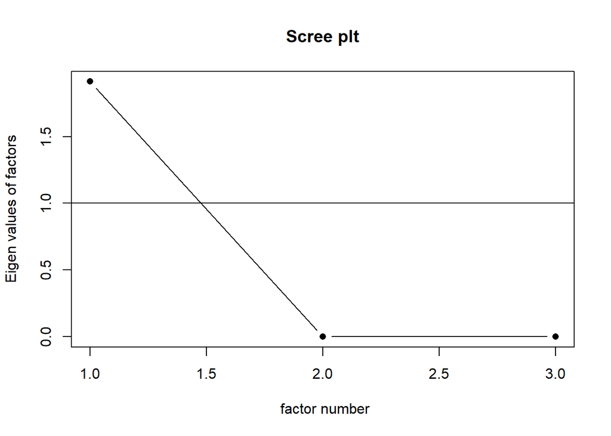

```r
scree(scale_4.1,factors=TRUE,pc=FALSE,main="Scree plt",hline=NULL,add=FALSE)
```

```r
alpha(scale_4.1) #.80
```

```
##
## Reliability analysis
## Call: alpha(x = scale_4.1)
##
##   raw_alpha std.alpha G6(smc) average_r S/N   ase mean   sd median_r
##        0.8      0.82    0.78       0.6 4.5 0.037  3.2 0.41      0.5
##
##     95% confidence boundaries
##          lower alpha upper
## Feldt     0.72   0.8  0.86
## Duhachek  0.73   0.8  0.88
##
##  Reliability if an item is dropped:
##        raw_alpha std.alpha G6(smc) average_r S/N alpha se var.r med.r
## q54_p1      0.89      0.89     0.8       0.8 7.8    0.023    NA   0.8
## q56_p1      0.66      0.67     0.5       0.5 2.0    0.068    NA   0.5
## q57_p1      0.66      0.66     0.5       0.5 2.0    0.069    NA   0.5
##
##  Item statistics
##         n raw.r std.r r.cor r.drop mean   sd
## q54_p1 94  0.81  0.78  0.56   0.53  3.2 0.53
## q56_p1 92  0.88  0.89  0.85   0.73  3.2 0.44
## q57_p1 93  0.88  0.90  0.86   0.73  3.2 0.44
##
## Non missing response frequency for each item
##           1    2    3    4 miss
## q54_p1 0.01 0.04 0.72 0.22 0.00
## q56_p1 0.00 0.03 0.78 0.18 0.02
## q57_p1 0.00 0.03 0.78 0.18 0.01
```

# Parent’s Value and Support of Education (6) <<<#matrix not positive definitive>>>

```r
#Parent’s Value and Support of Education (6)
scale_8 <- efa_vars %>%
  select(q105_p1:q110_p1)

# Poly corr matrix
poly_scale_8 <- polychoric(scale_8)
```

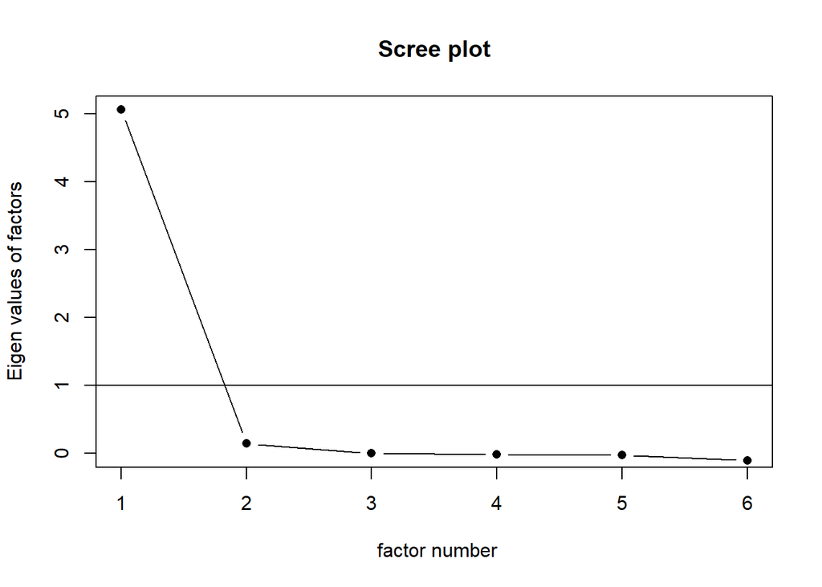

```r
poly_scale_8_mat <- data.frame(poly_scale_8$rho)

# scree plot
scree(poly_scale_8_mat,factors=TRUE,pc=FALSE,main="Scree plot",hline=NULL,add=FALSE)
```

```r
# EFA
fa(scale_8, n.obs = NA, rotate = "none", fm = "uls", cor = "poly")
```

```
## Factor Analysis using method =  uls
## Call: fa(r = scale_8, n.obs = NA, rotate = "none", fm = "uls", cor = "poly")
## Standardized loadings (pattern matrix) based upon correlation matrix
##         ULS1   h2    u2 com
## q105_p1 0.88 0.77 0.233   1
## q106_p1 0.99 0.98 0.017   1
## q107_p1 0.95 0.90 0.099   1
## q108_p1 0.98 0.95 0.046   1
## q109_p1 0.96 0.92 0.081   1
## q110_p1 0.73 0.53 0.468   1
##
##                ULS1
## SS loadings    5.06
## Proportion Var 0.84
##
## Mean item complexity =  1
## Test of the hypothesis that 1 factor is sufficient.
##
## The degrees of freedom for the null model are  15  and the objective function was  29.29 with Chi Square of  2641.11
## The degrees of freedom for the model are 9  and the objective function was  20.43
##
## The root mean square of the residuals (RMSR) is  0.03
## The df corrected root mean square of the residuals is  0.04
##
## The harmonic number of observations is  94 with the empirical chi square  3.02  with prob <  0.96
## The total number of observations was  94  with Likelihood Chi Square =  1828.93  with prob <  0
##
## Tucker Lewis Index of factoring reliability =  -0.164
## RMSEA index =  1.467  and the 90 % confidence intervals are  1.418 1.532
## BIC =  1788.04
## Fit based upon off diagonal values = 1
```

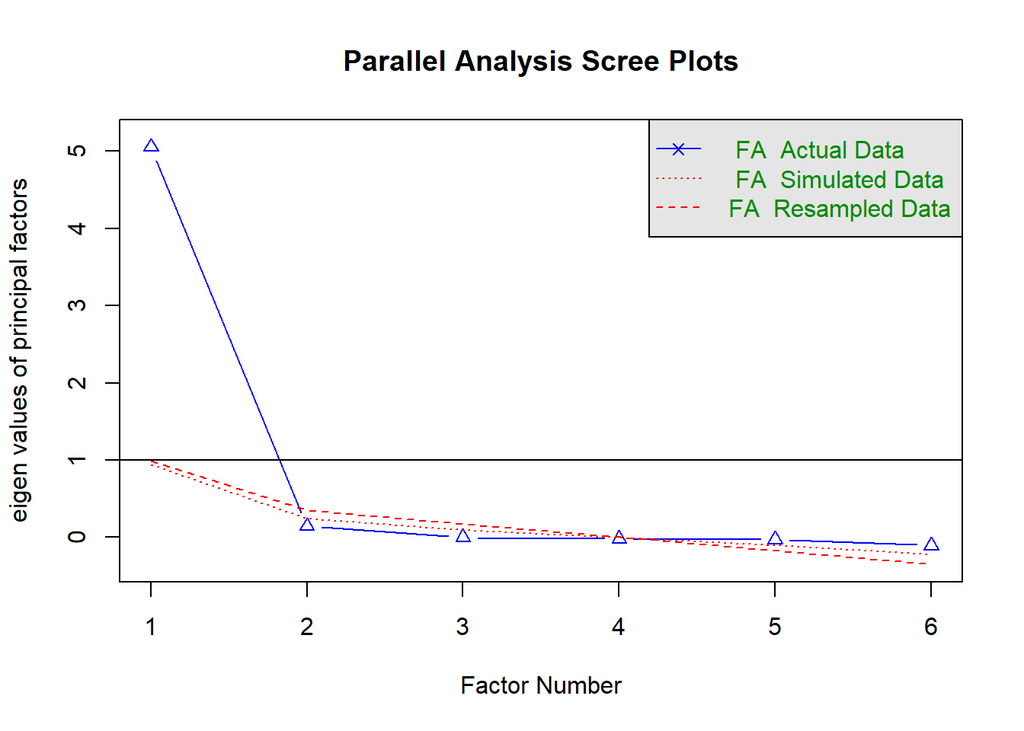

```
## Parallel analysis suggests that the number of factors =  1  and the number of components =  NA
```

```r
#Parent’s Value and Support of Education (6)
fa.parallel(scale_8, n.obs=NULL, fm="uls", fa="fa", nfactors=1, main="Parallel Analysis Scree Plots", n.iter=20, error.bars=FALSE, se.bars=FALSE, SMC=FALSE, ylabel=NULL, show.legend=TRUE, sim=TRUE, quant=.95, cor="poly", use="pairwise", plot=TRUE, correct=.5) # suggest 1 factor
```

```r
# RELIABILITY Parent’s Value and Support of Education (6)

alpha(scale_8) # .91
```

```
##
## Reliability analysis
## Call: alpha(x = scale_8)
##
##   raw_alpha std.alpha G6(smc) average_r S/N   ase mean   sd median_r
##       0.91      0.92    0.92      0.64  11 0.014  3.5 0.43      0.6
##
##     95% confidence boundaries
##          lower alpha upper
## Feldt     0.88  0.91  0.94
## Duhachek  0.89  0.91  0.94
##
##  Reliability if an item is dropped:
##         raw_alpha std.alpha G6(smc) average_r  S/N alpha se  var.r med.r
## q105_p1      0.91      0.91    0.90      0.67 10.0    0.016 0.0110  0.70
## q106_p1      0.89      0.89    0.88      0.62  8.1    0.018 0.0150  0.59
## q107_p1      0.89      0.90    0.90      0.63  8.6    0.018 0.0182  0.59
## q108_p1      0.89      0.89    0.89      0.62  8.1    0.019 0.0153  0.60
## q109_p1      0.89      0.89    0.89      0.63  8.3    0.018 0.0171  0.60
## q110_p1      0.92      0.92    0.93      0.71 12.0    0.013 0.0076  0.72
##
##  Item statistics
##          n raw.r std.r r.cor r.drop mean   sd
## q105_p1 93  0.79  0.79  0.76   0.69  3.6 0.49
## q106_p1 94  0.88  0.89  0.88   0.83  3.6 0.49
## q107_p1 94  0.86  0.86  0.83   0.79  3.5 0.52
## q108_p1 94  0.89  0.89  0.88   0.84  3.5 0.50
## q109_p1 94  0.88  0.88  0.86   0.82  3.5 0.50
## q110_p1 94  0.73  0.72  0.62   0.60  3.4 0.56
##
## Non missing response frequency for each item
##            1    2    3    4 miss
## q105_p1 0.00 0.00 0.39 0.61 0.01
## q106_p1 0.00 0.00 0.39 0.61 0.00
## q107_p1 0.00 0.01 0.48 0.51 0.00
## q108_p1 0.00 0.00 0.52 0.48 0.00
## q109_p1 0.00 0.00 0.52 0.48 0.00
## q110_p1 0.01 0.00 0.53 0.46 0.00
```

```r
# scale_8 %>%
#   mutate(q105_p1 = as.factor(q105_p1),
#          q106_p1 = as.factor(q106_p1),
#          q107_p1 = as.factor(q107_p1),
#          q108_p1 = as.factor(q108_p1),
#          q109_p1 = as.factor(q109_p1),
#          q110_p1 = as.factor(q110_p1)) %>%
#   summary()
```

```r
# Parent’s Value and Support of Education (6)
# plots3 <- split.default(scale_8, names(scale_8)) %>%
#   map(., setNames, nm = "var") %>%
#   map(., rownames_to_column) %>%
#   imap(., ~ {
#     ggplot(.x, aes(var)) +
#       geom_bar() +
#       labs(title = .y)
#     })
#
# plots3
```

# Parent-Teacher Relationship (4) <<< ultra-Heywood case>>>

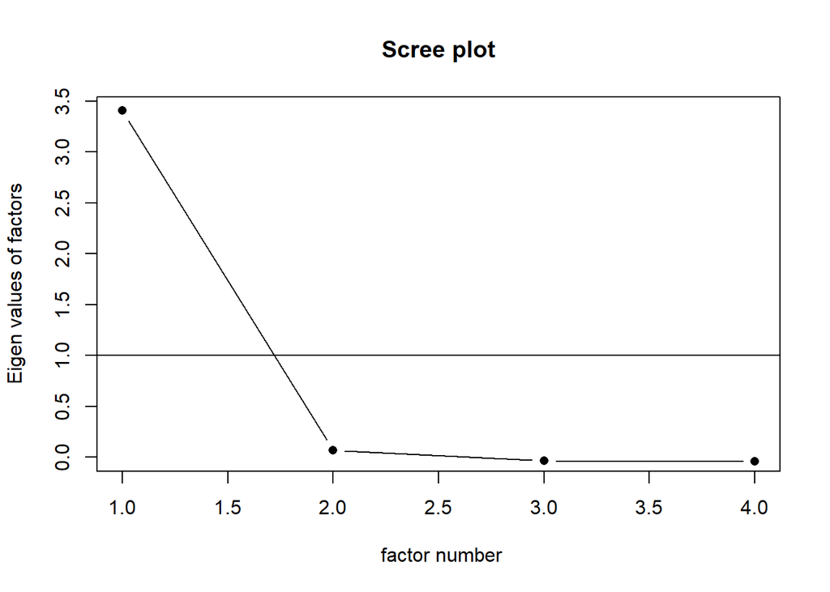

```r
# Parent-Teacher Relationship (4)
scale_5 <- efa_vars %>%
  select(q64_p1:q67_p1)

# Poly corr matrix
poly_scale_5 <- polychoric(scale_5)
poly_scale_5_mat <- data.frame(poly_scale_5$rho)

# scree plot
scree(poly_scale_5_mat,factors=TRUE,pc=FALSE,main="Scree plot",hline=NULL,add=FALSE)
```

```r
# EFA
fa(scale_5, n.obs = NA, rotate = "none", fm = "uls", cor = "poly")
```

```
## Factor Analysis using method =  uls
## Call: fa(r = scale_5, n.obs = NA, rotate = "none", fm = "uls", cor = "poly")
## Standardized loadings (pattern matrix) based upon correlation matrix
##        ULS1   h2      u2 com
## q64_p1 0.80 0.64  0.3618   1
## q65_p1 0.88 0.78  0.2226   1
## q66_p1 1.00 1.00 -0.0025   1
## q67_p1 0.99 0.99  0.0149   1
##
##                ULS1
## SS loadings    3.40
## Proportion Var 0.85
##
## Mean item complexity =  1
## Test of the hypothesis that 1 factor is sufficient.
##
## The degrees of freedom for the null model are  6  and the objective function was  6.73 with Chi Square of  610.86
## The degrees of freedom for the model are 2  and the objective function was  1.64
##
## The root mean square of the residuals (RMSR) is  0.03
## The df corrected root mean square of the residuals is  0.04
##
## The harmonic number of observations is  91 with the empirical chi square  0.7  with prob <  0.71
## The total number of observations was  94  with Likelihood Chi Square =  147.54  with prob <  9.2e-33
##
## Tucker Lewis Index of factoring reliability =  0.273
## RMSEA index =  0.88  and the 90 % confidence intervals are  0.767 1.008
## BIC =  138.45
## Fit based upon off diagonal values = 1
```

```r
alpha(scale_5) #.87
```

```
##
## Reliability analysis
## Call: alpha(x = scale_5)
##
##   raw_alpha std.alpha G6(smc) average_r S/N   ase mean   sd median_r
##       0.87      0.87    0.86      0.63 6.8 0.021  3.1 0.46     0.61
##
##     95% confidence boundaries
##          lower alpha upper
## Feldt     0.82  0.87  0.91
## Duhachek  0.83  0.87  0.91
##
##  Reliability if an item is dropped:
##        raw_alpha std.alpha G6(smc) average_r S/N alpha se  var.r med.r
## q64_p1      0.88      0.89    0.86      0.72 7.8    0.022 0.0119  0.68
## q65_p1      0.85      0.85    0.82      0.65 5.6    0.026 0.0291  0.58
## q66_p1      0.80      0.80    0.74      0.57 4.0    0.035 0.0085  0.53
## q67_p1      0.80      0.80    0.74      0.58 4.1    0.035 0.0040  0.58
##
##  Item statistics
##         n raw.r std.r r.cor r.drop mean   sd
## q64_p1 93  0.74  0.77  0.63   0.60  3.2 0.46
## q65_p1 89  0.85  0.83  0.74   0.70  3.0 0.56
## q66_p1 93  0.92  0.90  0.89   0.81  3.1 0.57
## q67_p1 92  0.91  0.90  0.89   0.82  3.1 0.50
##
## Non missing response frequency for each item
##           2    3    4 miss
## q64_p1 0.02 0.75 0.23 0.01
## q65_p1 0.15 0.69 0.17 0.05
## q66_p1 0.13 0.68 0.19 0.01
## q67_p1 0.10 0.75 0.15 0.02
```

```r
### -----Parent-Teacher Relationship (4) ----- ###

# EFA without q66_p1 = bec it had a negative u2 and a factor loading of 1
scale_5.1 <- efa_vars %>%
  select(q64_p1, q65_p1, q67_p1)

fa(scale_5.1, n.obs = NA, rotate = "none", fm = "uls", cor = "poly") # another ultra-heywood, item 67
```

```
## Factor Analysis using method =  uls
## Call: fa(r = scale_5.1, n.obs = NA, rotate = "none", fm = "uls", cor = "poly")
## Standardized loadings (pattern matrix) based upon correlation matrix
##        ULS1   h2      u2 com
## q64_p1 0.77 0.59  0.4148   1
## q65_p1 0.90 0.81  0.1887   1
## q67_p1 1.00 1.00 -0.0036   1
##
##                ULS1
## SS loadings     2.4
## Proportion Var  0.8
##
## Mean item complexity =  1
## Test of the hypothesis that 1 factor is sufficient.
##
## The degrees of freedom for the null model are  3  and the objective function was  2.64 with Chi Square of  240.86
## The degrees of freedom for the model are 0  and the objective function was  0
##
## The root mean square of the residuals (RMSR) is  0.01
## The df corrected root mean square of the residuals is  NA
##
## The harmonic number of observations is  90 with the empirical chi square  0.02  with prob <  NA
## The total number of observations was  94  with Likelihood Chi Square =  0.44  with prob <  NA
##
## Tucker Lewis Index of factoring reliability =  -Inf
## Fit based upon off diagonal values = 1
```

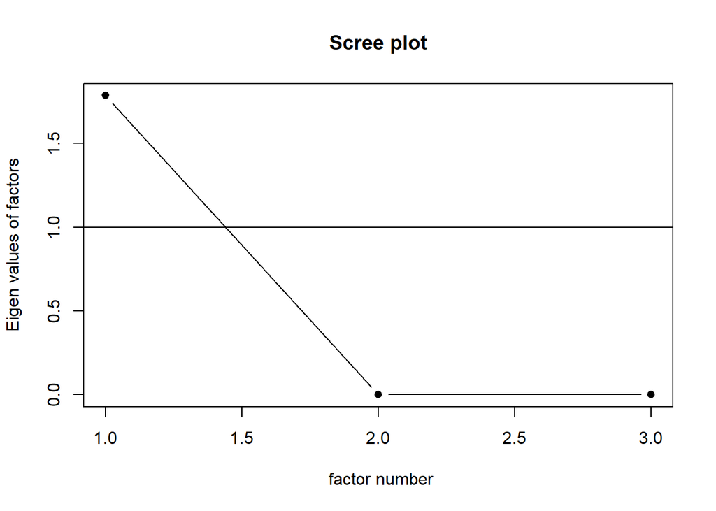

```r
scree(scale_5.1,factors=TRUE,pc=FALSE,main="Scree plot",hline=NULL,add=FALSE)
```

```r
alpha(scale_5.1) #.80
```

```
##
## Reliability analysis
## Call: alpha(x = scale_5.1)
##
##   raw_alpha std.alpha G6(smc) average_r S/N   ase mean   sd median_r
##        0.8       0.8    0.74      0.57   4 0.035  3.1 0.43     0.53
##
##     95% confidence boundaries
##          lower alpha upper
## Feldt     0.72   0.8  0.86
## Duhachek  0.73   0.8  0.87
##
##  Reliability if an item is dropped:
##        raw_alpha std.alpha G6(smc) average_r S/N alpha se var.r med.r
## q64_p1      0.81      0.81    0.68      0.68 4.2    0.040    NA  0.68
## q65_p1      0.69      0.69    0.53      0.53 2.2    0.064    NA  0.53
## q67_p1      0.67      0.68    0.51      0.51 2.1    0.067    NA  0.51
##
##  Item statistics
##         n raw.r std.r r.cor r.drop mean   sd
## q64_p1 93  0.78  0.80  0.62   0.57  3.2 0.46
## q65_p1 89  0.88  0.86  0.77   0.69  3.0 0.56
## q67_p1 92  0.88  0.87  0.79   0.70  3.1 0.50
##
## Non missing response frequency for each item
##           2    3    4 miss
## q64_p1 0.02 0.75 0.23 0.01
## q65_p1 0.15 0.69 0.17 0.05
## q67_p1 0.10 0.75 0.15 0.02
```

```r
# EFA without q67_p1 = bec it had a factor loading of 0.99
scale_5.2 <- efa_vars %>%
  select(q64_p1, q65_p1) # not reasonable a 2 item scale

fa(scale_5.2, n.obs = NA, rotate = "none", fm = "uls", cor = "poly")
```

```
## Factor Analysis using method =  uls
## Call: fa(r = scale_5.2, n.obs = NA, rotate = "none", fm = "uls", cor = "poly")
## Standardized loadings (pattern matrix) based upon correlation matrix
##        ULS1   h2   u2 com
## q64_p1 0.83 0.68 0.32   1
## q65_p1 0.83 0.68 0.32   1
##
##                ULS1
## SS loadings    1.37
## Proportion Var 0.68
##
## Mean item complexity =  1
## Test of the hypothesis that 1 factor is sufficient.
##
## The degrees of freedom for the null model are  1  and the objective function was  0.63 with Chi Square of  57.43
## The degrees of freedom for the model are -1  and the objective function was  0
##
## The root mean square of the residuals (RMSR) is  0
## The df corrected root mean square of the residuals is  NA
##
## The harmonic number of observations is  90 with the empirical chi square  0  with prob <  NA
## The total number of observations was  94  with Likelihood Chi Square =  0  with prob <  NA
##
## Tucker Lewis Index of factoring reliability =  1.018
## Fit based upon off diagonal values = 1
## Measures of factor score adequacy
##                                                   ULS1
## Correlation of (regression) scores with factors   0.90
## Multiple R square of scores with factors          0.81
## Minimum correlation of possible factor scores     0.62
```

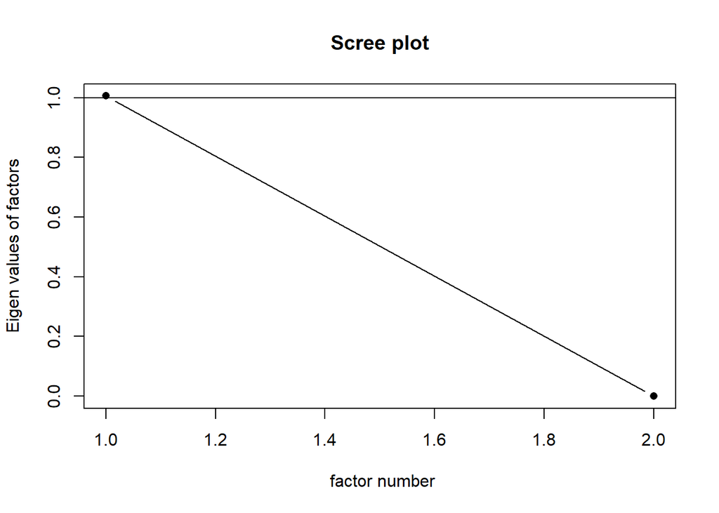

```r
scree(scale_5.2,factors=TRUE,pc=FALSE,main="Scree plot",hline=NULL,add=FALSE)
```

```r
alpha(scale_5.2)#.67
```

```
##
## Reliability analysis
## Call: alpha(x = scale_5.2)
##
##   raw_alpha std.alpha G6(smc) average_r S/N   ase mean   sd median_r
##       0.67      0.68    0.51      0.51 2.1 0.067  3.1 0.44     0.51
##
##     95% confidence boundaries
##          lower alpha upper
## Feldt     0.50  0.67  0.78
## Duhachek  0.54  0.67  0.80
##
##  Reliability if an item is dropped:
##        raw_alpha std.alpha G6(smc) average_r S/N alpha se var.r med.r
## q64_p1      0.41      0.51    0.26      0.51   1       NA     0  0.51
## q65_p1      0.63      0.51    0.26      0.51   1       NA     0  0.51
##
##  Item statistics
##         n raw.r std.r r.cor r.drop mean   sd
## q64_p1 93  0.84  0.87  0.62   0.51  3.2 0.46
## q65_p1 89  0.89  0.87  0.62   0.51  3.0 0.56
##
## Non missing response frequency for each item
##           2    3    4 miss
## q64_p1 0.02 0.75 0.23 0.01
## q65_p1 0.15 0.69 0.17 0.05
```

# Family-School Communication (6)

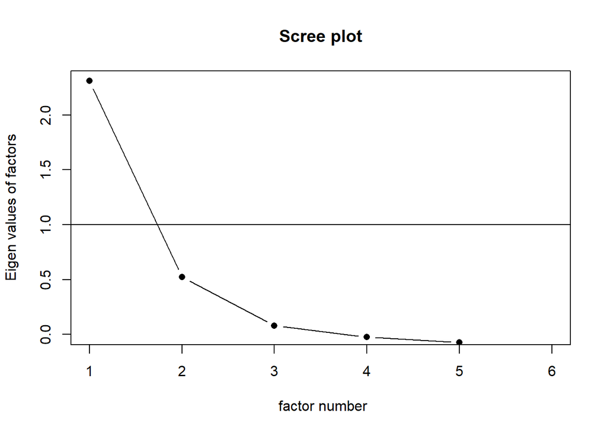

```r
#Family-School Communication (6)
scale_11 <- efa_vars %>%
  select(q18_p1, q19_p1, q41_p1, q43_p1, q50_p1, q62_p1)

# Poly corr matrix
poly_scale_11 <- polychoric(scale_11)
poly_scale_11_mat <- data.frame(poly_scale_11$rho)

# scree plot
scree(poly_scale_11_mat,factors=TRUE,pc=FALSE,main="Scree plot",hline=NULL,add=FALSE)
```

```r
# EFA
fa(scale_11, n.obs = NA, rotate = "none", fm = "uls", cor = "poly")
```

```
## Factor Analysis using method =  uls
## Call: fa(r = scale_11, n.obs = NA, rotate = "none", fm = "uls", cor = "poly")
## Standardized loadings (pattern matrix) based upon correlation matrix
##        ULS1    h2    u2 com
## q18_p1 0.16 0.024 0.976   1
## q19_p1 0.22 0.047 0.953   1
## q41_p1 0.58 0.334 0.666   1
## q43_p1 0.76 0.575 0.425   1
## q50_p1 0.95 0.908 0.092   1
## q62_p1 0.65 0.422 0.578   1
##
##                ULS1
## SS loadings    2.31
## Proportion Var 0.38
##
## Mean item complexity =  1
## Test of the hypothesis that 1 factor is sufficient.
##
## The degrees of freedom for the null model are  15  and the objective function was  2.06 with Chi Square of  185.7
## The degrees of freedom for the model are 9  and the objective function was  0.36
##
## The root mean square of the residuals (RMSR) is  0.13
## The df corrected root mean square of the residuals is  0.17
##
## The harmonic number of observations is  93 with the empirical chi square  50.69  with prob <  8e-08
## The total number of observations was  94  with Likelihood Chi Square =  32.45  with prob <  0.00017
##
## Tucker Lewis Index of factoring reliability =  0.769
## RMSEA index =  0.166  and the 90 % confidence intervals are  0.108 0.231
## BIC =  -8.44
## Fit based upon off diagonal values = 0.88
## Measures of factor score adequacy
##                                                   ULS1
## Correlation of (regression) scores with factors   0.96
## Multiple R square of scores with factors          0.93
## Minimum correlation of possible factor scores     0.85
```

```r
#Family-School Communication (4)
scale_11.2 <- efa_vars %>%
  select(q41_p1, q43_p1, q50_p1, q62_p1)

# EFA
fa(scale_11.2, n.obs = NA, rotate = "none", fm = "uls", cor = "poly")
```

```
## Factor Analysis using method =  uls
## Call: fa(r = scale_11.2, n.obs = NA, rotate = "none", fm = "uls", cor = "poly")
## Standardized loadings (pattern matrix) based upon correlation matrix
##        ULS1   h2    u2 com
## q41_p1 0.59 0.34 0.657   1
## q43_p1 0.76 0.58 0.417   1
## q50_p1 0.95 0.91 0.094   1
## q62_p1 0.65 0.43 0.575   1
##
##                ULS1
## SS loadings    2.26
## Proportion Var 0.56
##
## Mean item complexity =  1
## Test of the hypothesis that 1 factor is sufficient.
##
## The degrees of freedom for the null model are  6  and the objective function was  1.68 with Chi Square of  152.56
## The degrees of freedom for the model are 2  and the objective function was  0.03
##
## The root mean square of the residuals (RMSR) is  0.03
## The df corrected root mean square of the residuals is  0.06
##
## The harmonic number of observations is  93 with the empirical chi square  1.16  with prob <  0.56
## The total number of observations was  94  with Likelihood Chi Square =  2.79  with prob <  0.25
##
## Tucker Lewis Index of factoring reliability =  0.984
## RMSEA index =  0.064  and the 90 % confidence intervals are  0 0.227
## BIC =  -6.3
## Fit based upon off diagonal values = 1
## Measures of factor score adequacy
##                                                   ULS1
## Correlation of (regression) scores with factors   0.96
## Multiple R square of scores with factors          0.92
## Minimum correlation of possible factor scores     0.85
```

# Problem Solving with Educators (4)

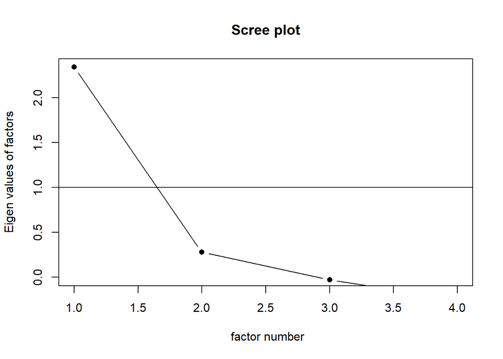

```r
#Problem Solving with Educators (4)
scale_12 <- efa_vars %>%
  select(q44_p1, q58_p1, q63_p1, q126_p1)

# Poly corr matrix
poly_scale_12 <- polychoric(scale_12)
poly_scale_12_mat <- data.frame(poly_scale_12$rho)

# scree plot
scree(poly_scale_12_mat,factors=TRUE,pc=FALSE,main="Scree plot",hline=NULL,add=FALSE)
```

```r
# EFA
fa(scale_12, n.obs = NA, rotate = "none", fm = "uls", cor = "poly")
```

```
## Factor Analysis using method =  uls
## Call: fa(r = scale_12, n.obs = NA, rotate = "none", fm = "uls", cor = "poly")
## Standardized loadings (pattern matrix) based upon correlation matrix
##         ULS1   h2   u2 com
## q44_p1  0.67 0.44 0.56   1
## q58_p1  0.90 0.81 0.19   1
## q63_p1  0.96 0.93 0.07   1
## q126_p1 0.39 0.16 0.84   1
##
##                ULS1
## SS loadings    2.34
## Proportion Var 0.59
##
## Mean item complexity =  1
## Test of the hypothesis that 1 factor is sufficient.
##
## The degrees of freedom for the null model are  6  and the objective function was  2.92 with Chi Square of  264.98
## The degrees of freedom for the model are 2  and the objective function was  0.54
##
## The root mean square of the residuals (RMSR) is  0.11
## The df corrected root mean square of the residuals is  0.19
##
## The harmonic number of observations is  90 with the empirical chi square  12.77  with prob <  0.0017
## The total number of observations was  94  with Likelihood Chi Square =  48.89  with prob <  2.4e-11
##
## Tucker Lewis Index of factoring reliability =  0.453
## RMSEA index =  0.499  and the 90 % confidence intervals are  0.386 0.629
## BIC =  39.8
## Fit based upon off diagonal values = 0.96
## Measures of factor score adequacy
##                                                   ULS1
## Correlation of (regression) scores with factors   0.98
## Multiple R square of scores with factors          0.95
## Minimum correlation of possible factor scores     0.90
```

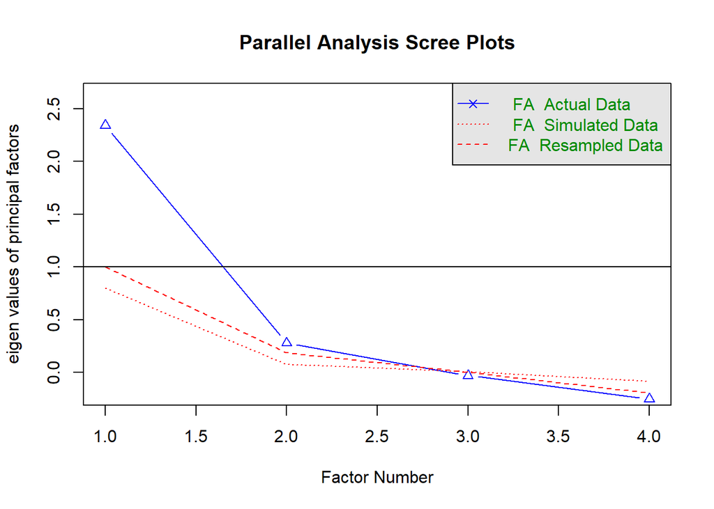

```
## Parallel analysis suggests that the number of factors =  2  and the number of components =  NA
```

```r
#Problem Solving with Educators (4)
fa.parallel(scale_12, n.obs=NULL, fm="uls", fa="fa", nfactors=1, main="Parallel Analysis Scree Plots", n.iter=20, error.bars=FALSE, se.bars=FALSE, SMC=FALSE, ylabel=NULL, show.legend=TRUE, sim=TRUE, quant=.95, cor="poly", use="pairwise", plot=TRUE, correct=.5) # suggest 2 factors, but one appears to be an eigenvalue less than 1
```

```r
# EFA 2 factors
fa(scale_12, nfactors = 2, n.obs = NA, rotate = "quartimin", fm = "uls", cor = "poly") # with 2 factors shows ultra-heywood case, also would be each factor with just 2 items
```

```
## Factor Analysis using method =  uls
## Call: fa(r = scale_12, nfactors = 2, n.obs = NA, rotate = "quartimin",
##     fm = "uls", cor = "poly")
## Standardized loadings (pattern matrix) based upon correlation matrix
##         ULS1  ULS2   h2      u2 com
## q44_p1  0.50  0.32 0.45  0.5488 1.7
## q58_p1  1.02 -0.08 1.00 -0.0049 1.0
## q63_p1  0.91  0.08 0.88  0.1242 1.0
## q126_p1 0.00  1.00 1.00  0.0038 1.0
##
##                       ULS1 ULS2
## SS loadings           2.17 1.16
## Proportion Var        0.54 0.29
## Cumulative Var        0.54 0.83
## Proportion Explained  0.65 0.35
## Cumulative Proportion 0.65 1.00
##
##  With factor correlations of
##      ULS1 ULS2
## ULS1 1.00 0.31
## ULS2 0.31 1.00
##
## Mean item complexity =  1.2
## Test of the hypothesis that 2 factors are sufficient.
##
## The degrees of freedom for the null model are  6  and the objective function was  2.92 with Chi Square of  264.98
## The degrees of freedom for the model are -1  and the objective function was  0.02
##
## The root mean square of the residuals (RMSR) is  0.01
## The df corrected root mean square of the residuals is  NA
##
## The harmonic number of observations is  90 with the empirical chi square  0.05  with prob <  NA
## The total number of observations was  94  with Likelihood Chi Square =  1.75  with prob <  NA
##
## Tucker Lewis Index of factoring reliability =  1.065
## Fit based upon off diagonal values = 1
```

```r
#Reliability: Problem Solving with Educators (4)

alpha(scale_12) # 0.71; if removing items 126 would be .79
```

```
##
## Reliability analysis
## Call: alpha(x = scale_12)
##
##   raw_alpha std.alpha G6(smc) average_r S/N   ase mean   sd median_r
##       0.71      0.71    0.71      0.38 2.4 0.051  3.1 0.36     0.34
##
##     95% confidence boundaries
##          lower alpha upper
## Feldt     0.59  0.71  0.79
## Duhachek  0.61  0.71  0.80
##
##  Reliability if an item is dropped:
##         raw_alpha std.alpha G6(smc) average_r S/N alpha se var.r med.r
## q44_p1       0.63      0.64    0.66      0.37 1.8    0.069 0.118  0.20
## q58_p1       0.56      0.56    0.47      0.30 1.3    0.080 0.013  0.26
## q63_p1       0.55      0.55    0.48      0.29 1.2    0.081 0.025  0.26
## q126_p1      0.79      0.79    0.75      0.55 3.7    0.039 0.036  0.46
##
##  Item statistics
##          n raw.r std.r r.cor r.drop mean   sd
## q44_p1  93  0.75  0.74  0.57   0.50  3.1 0.48
## q58_p1  92  0.81  0.82  0.81   0.62  3.1 0.48
## q63_p1  91  0.81  0.82  0.81   0.64  3.2 0.45
## q126_p1 92  0.60  0.55  0.28   0.25  3.1 0.49
##
## Non missing response frequency for each item
##            1    2    3    4 miss
## q44_p1  0.00 0.06 0.76 0.17 0.01
## q58_p1  0.00 0.05 0.75 0.20 0.02
## q63_p1  0.00 0.03 0.77 0.20 0.03
## q126_p1 0.01 0.03 0.78 0.17 0.02
```

# Combined scale: Parent-Teacher Relationship (4), Family-School Communication (6), Problem Solving with Educators (4)

q64_p1, q65_p1, q66_p1, q67_p1 –> parent-teacher rel

q18_p1, q19_p1, q41_p1, q43_p1, q50_p1, q62_p1 –> communication

q44_p1, q58_p1, q63_p1, q126_p1 –> problem solving

```r
# rel combined
scale_comb <- efa_vars %>%
  select(q18_p1, q19_p1, q41_p1, q43_p1, q44_p1, q50_p1, q58_p1, q62_p1, q63_p1, q64_p1, q65_p1, q66_p1, q67_p1, q126_p1) # items 18 and 19 loading less than .30

scale_comb <- efa_vars %>%
  select(q41_p1, q43_p1, q44_p1, q50_p1, q58_p1, q62_p1, q63_p1, q64_p1, q65_p1, q66_p1, q67_p1, q126_p1)

# Poly corr matrix
poly_scale_comb <- polychoric(scale_comb)
```

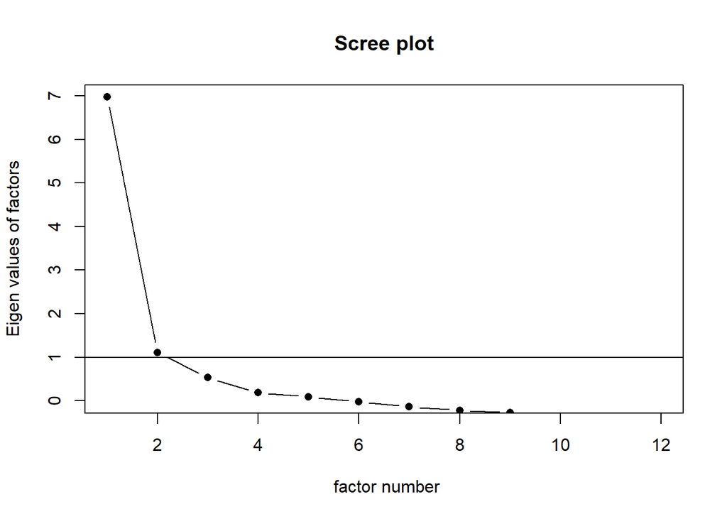

```r
poly_scale_comb_mat <- data.frame(poly_scale_comb$rho)

# scree plot
scree(poly_scale_comb_mat,factors=TRUE,pc=FALSE,main="Scree plot",hline=NULL,add=FALSE)
```

```r
# EFA rel combined
fa(scale_comb, n.obs = NA, rotate = "none", fm = "uls", cor = "poly") # matrix not positive definite, but looks good
```

```
## In factor.stats, I could not find the RMSEA upper bound . Sorry about that
```

```
## Factor Analysis using method =  uls
## Call: fa(r = scale_comb, n.obs = NA, rotate = "none", fm = "uls", cor = "poly")
## Standardized loadings (pattern matrix) based upon correlation matrix
##         ULS1   h2   u2 com
## q41_p1  0.61 0.38 0.62   1
## q43_p1  0.67 0.45 0.55   1
## q44_p1  0.69 0.48 0.52   1
## q50_p1  0.76 0.57 0.43   1
## q58_p1  0.84 0.70 0.30   1
## q62_p1  0.81 0.66 0.34   1
## q63_p1  0.84 0.71 0.29   1
## q64_p1  0.81 0.65 0.35   1
## q65_p1  0.83 0.69 0.31   1
## q66_p1  0.82 0.67 0.33   1
## q67_p1  0.89 0.79 0.21   1
## q126_p1 0.47 0.22 0.78   1
##
##                ULS1
## SS loadings    6.97
## Proportion Var 0.58
##
## Mean item complexity =  1
## Test of the hypothesis that 1 factor is sufficient.
##
## The degrees of freedom for the null model are  66  and the objective function was  74.53 with Chi Square of  6571.08
## The degrees of freedom for the model are 54  and the objective function was  66.24
##
## The root mean square of the residuals (RMSR) is  0.13
## The df corrected root mean square of the residuals is  0.14
##
## The harmonic number of observations is  91 with the empirical chi square  204.5  with prob <  2.3e-19
## The total number of observations was  94  with Likelihood Chi Square =  5796.04  with prob <  0
##
## Tucker Lewis Index of factoring reliability =  -0.087
## RMSEA index =  1.064  and the 90 % confidence intervals are  1.046 NA
## BIC =  5550.7
## Fit based upon off diagonal values = 0.95
```

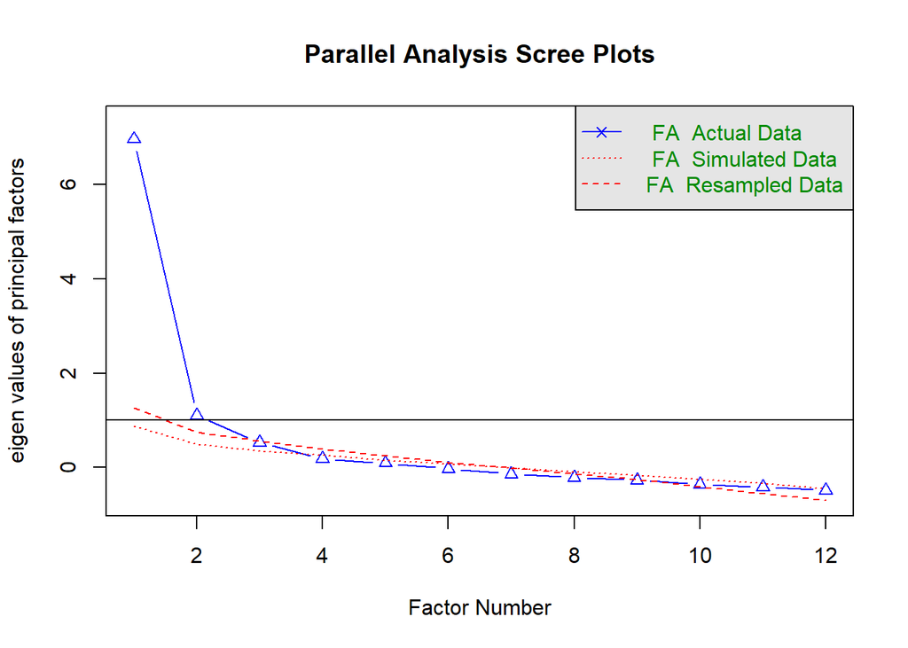

```
## Parallel analysis suggests that the number of factors =  3  and the number of components =  NA
```

```r
# rel combined
fa.parallel(scale_comb, n.obs=NULL, fm="uls", fa="fa", nfactors=1, main="Parallel Analysis Scree Plots", n.iter=20, error.bars=FALSE, se.bars=FALSE, SMC=FALSE, ylabel=NULL, show.legend=TRUE, sim=TRUE, quant=.95, cor="poly", use="pairwise", plot=TRUE, correct=.5) # parallel analysis suggest 3 factors, matrix not positive,  ultra heywood
```

```r
# 3 factors
fa(scale_comb, nfactors = 3, n.obs = NA, rotate = "quartimin", fm = "uls", cor = "poly") # 66 was Heywood, other 3 items were crossloading
```

```
## In factor.stats, I could not find the RMSEA upper bound . Sorry about that
```

```
## Factor Analysis using method =  uls
## Call: fa(r = scale_comb, nfactors = 3, n.obs = NA, rotate = "quartimin",
##     fm = "uls", cor = "poly")
## Standardized loadings (pattern matrix) based upon correlation matrix
##          ULS1  ULS2  ULS3   h2      u2 com
## q41_p1   0.38  0.24  0.12 0.38  0.6240 1.9
## q43_p1   0.16  0.83 -0.11 0.74  0.2568 1.1
## q44_p1  -0.16  0.86  0.24 0.85  0.1458 1.2
## q50_p1   0.00  0.87  0.13 0.89  0.1065 1.0
## q58_p1   0.02  0.13  0.87 0.92  0.0810 1.0
## q62_p1   0.35  0.06  0.55 0.71  0.2861 1.7
## q63_p1   0.15  0.13  0.74 0.82  0.1772 1.1
## q64_p1   0.37 -0.06  0.65 0.79  0.2128 1.6
## q65_p1   0.67  0.16  0.16 0.74  0.2561 1.2
## q66_p1   1.01 -0.03  0.01 1.00 -0.0033 1.0
## q67_p1   0.86  0.05  0.15 0.97  0.0308 1.1
## q126_p1  0.29  0.64 -0.31 0.45  0.5493 1.9
##
##                       ULS1 ULS2 ULS3
## SS loadings           3.37 3.06 2.85
## Proportion Var        0.28 0.26 0.24
## Cumulative Var        0.28 0.54 0.77
## Proportion Explained  0.36 0.33 0.31
## Cumulative Proportion 0.36 0.69 1.00
##
##  With factor correlations of
##      ULS1 ULS2 ULS3
## ULS1 1.00 0.44 0.59
## ULS2 0.44 1.00 0.50
## ULS3 0.59 0.50 1.00
##
## Mean item complexity =  1.3
## Test of the hypothesis that 3 factors are sufficient.
##
## The degrees of freedom for the null model are  66  and the objective function was  74.53 with Chi Square of  6571.08
## The degrees of freedom for the model are 33  and the objective function was  63.23
##
## The root mean square of the residuals (RMSR) is  0.05
## The df corrected root mean square of the residuals is  0.07
##
## The harmonic number of observations is  91 with the empirical chi square  29.03  with prob <  0.67
## The total number of observations was  94  with Likelihood Chi Square =  5448.3  with prob <  0
##
## Tucker Lewis Index of factoring reliability =  -0.704
## RMSEA index =  1.321  and the 90 % confidence intervals are  1.299 NA
## BIC =  5298.37
## Fit based upon off diagonal values = 0.99
```

```r
# rel combined - EFA 2 factors
fa(scale_comb, nfactors = 2, n.obs = NA, rotate = "quartimin", fm = "uls", cor = "poly")
```

```
## In factor.stats, I could not find the RMSEA upper bound . Sorry about that
```

```
## Factor Analysis using method =  uls
## Call: fa(r = scale_comb, nfactors = 2, n.obs = NA, rotate = "quartimin",
##     fm = "uls", cor = "poly")
## Standardized loadings (pattern matrix) based upon correlation matrix
##          ULS1  ULS2   h2    u2 com
## q41_p1   0.45  0.22 0.37 0.631 1.4
## q43_p1   0.03  0.83 0.71 0.292 1.0
## q44_p1  -0.02  0.92 0.82 0.175 1.0
## q50_p1   0.04  0.93 0.91 0.087 1.0
## q58_p1   0.70  0.19 0.70 0.301 1.2
## q62_p1   0.80  0.05 0.70 0.299 1.0
## q63_p1   0.74  0.16 0.71 0.288 1.1
## q64_p1   0.91 -0.07 0.75 0.247 1.0
## q65_p1   0.79  0.09 0.71 0.289 1.0
## q66_p1   0.96 -0.11 0.80 0.200 1.0
## q67_p1   0.97 -0.04 0.89 0.108 1.0
## q126_p1  0.00  0.58 0.34 0.662 1.0
##
##                       ULS1 ULS2
## SS loadings           5.37 3.05
## Proportion Var        0.45 0.25
## Cumulative Var        0.45 0.70
## Proportion Explained  0.64 0.36
## Cumulative Proportion 0.64 1.00
##
##  With factor correlations of
##      ULS1 ULS2
## ULS1  1.0  0.6
## ULS2  0.6  1.0
##
## Mean item complexity =  1.1
## Test of the hypothesis that 2 factors are sufficient.
##
## The degrees of freedom for the null model are  66  and the objective function was  74.53 with Chi Square of  6571.08
## The degrees of freedom for the model are 43  and the objective function was  63.82
##
## The root mean square of the residuals (RMSR) is  0.08
## The df corrected root mean square of the residuals is  0.09
##
## The harmonic number of observations is  91 with the empirical chi square  68.5  with prob <  0.008
## The total number of observations was  94  with Likelihood Chi Square =  5541.76  with prob <  0
##
## Tucker Lewis Index of factoring reliability =  -0.318
## RMSEA index =  1.166  and the 90 % confidence intervals are  1.147 NA
## BIC =  5346.4
## Fit based upon off diagonal values = 0.98
```

```r
scale_comb_fa1 <- efa_vars %>%
  select(q41_p1, q58_p1, q62_p1, q63_p1, q64_p1, q65_p1, q66_p1, q67_p1)

alpha(scale_comb_fa1) #.90
```

```
##
## Reliability analysis
## Call: alpha(x = scale_comb_fa1)
##
##   raw_alpha std.alpha G6(smc) average_r S/N   ase mean   sd median_r
##        0.9       0.9    0.92      0.53 9.2 0.016  3.1 0.39     0.52
##
##     95% confidence boundaries
##          lower alpha upper
## Feldt     0.86   0.9  0.93
## Duhachek  0.87   0.9  0.93
##
##  Reliability if an item is dropped:
##        raw_alpha std.alpha G6(smc) average_r S/N alpha se var.r med.r
## q41_p1      0.90      0.91    0.92      0.58 9.7    0.015 0.011  0.57
## q58_p1      0.88      0.89    0.90      0.53 7.8    0.018 0.015  0.53
## q62_p1      0.88      0.89    0.90      0.53 7.8    0.019 0.017  0.51
## q63_p1      0.88      0.89    0.90      0.53 7.7    0.018 0.017  0.52
## q64_p1      0.89      0.89    0.91      0.54 8.2    0.018 0.018  0.49
## q65_p1      0.89      0.89    0.91      0.54 8.1    0.018 0.019  0.53
## q66_p1      0.88      0.88    0.89      0.52 7.6    0.019 0.015  0.52
## q67_p1      0.88      0.88    0.89      0.52 7.5    0.019 0.015  0.49
##
##  Item statistics
##         n raw.r std.r r.cor r.drop mean   sd
## q41_p1 94  0.63  0.61  0.52   0.50  3.2 0.57
## q58_p1 92  0.77  0.79  0.77   0.71  3.1 0.48
## q62_p1 93  0.78  0.79  0.76   0.71  3.2 0.49
## q63_p1 91  0.78  0.80  0.78   0.72  3.2 0.45
## q64_p1 93  0.74  0.76  0.71   0.67  3.2 0.46
## q65_p1 89  0.79  0.77  0.72   0.69  3.0 0.56
## q66_p1 93  0.84  0.82  0.82   0.76  3.1 0.57
## q67_p1 92  0.84  0.82  0.82   0.77  3.1 0.50
##
## Non missing response frequency for each item
##           2    3    4 miss
## q41_p1 0.07 0.63 0.30 0.00
## q58_p1 0.05 0.75 0.20 0.02
## q62_p1 0.04 0.72 0.24 0.01
## q63_p1 0.03 0.77 0.20 0.03
## q64_p1 0.02 0.75 0.23 0.01
## q65_p1 0.15 0.69 0.17 0.05
## q66_p1 0.13 0.68 0.19 0.01
## q67_p1 0.10 0.75 0.15 0.02
```

```r
scale_comb_fa2 <- efa_vars %>%
  select(q43_p1, q44_p1, q50_p1, q126_p1)

alpha(scale_comb_fa2) #.78
```

```
##
## Reliability analysis
## Call: alpha(x = scale_comb_fa2)
##
##   raw_alpha std.alpha G6(smc) average_r S/N   ase mean  sd median_r
##       0.78      0.78    0.77      0.47 3.6 0.037  3.1 0.4     0.49
##
##     95% confidence boundaries
##          lower alpha upper
## Feldt     0.70  0.78  0.84
## Duhachek  0.71  0.78  0.85
##
##  Reliability if an item is dropped:
##         raw_alpha std.alpha G6(smc) average_r S/N alpha se var.r med.r
## q43_p1       0.70      0.70    0.67      0.43 2.3    0.056 0.062  0.32
## q44_p1       0.70      0.69    0.62      0.43 2.3    0.053 0.010  0.46
## q50_p1       0.69      0.69    0.63      0.43 2.2    0.053 0.022  0.46
## q126_p1      0.81      0.82    0.76      0.60 4.4    0.035 0.012  0.55
##
##  Item statistics
##          n raw.r std.r r.cor r.drop mean   sd
## q43_p1  94  0.83  0.81  0.72   0.65  3.0 0.57
## q44_p1  93  0.81  0.82  0.77   0.65  3.1 0.48
## q50_p1  93  0.81  0.82  0.77   0.65  3.1 0.48
## q126_p1 92  0.67  0.66  0.47   0.42  3.1 0.49
##
## Non missing response frequency for each item
##            1    2    3    4 miss
## q43_p1  0.01 0.12 0.71 0.16 0.00
## q44_p1  0.00 0.06 0.76 0.17 0.01
## q50_p1  0.01 0.03 0.80 0.16 0.01
## q126_p1 0.01 0.03 0.78 0.17 0.02
```